# Cluster analysis

```r
# install.packages("readxl")
# install.packages("tidyverse")
# install.packages("psych")
# install.packages("psychTools")
# install.packages("GPArotation")
# install.packages("corrplot")
library(corrplot)
library(readxl)
library(tidyverse)
library(psych)
library(psychTools)
library(GPArotation)
library(caret)
library(cluster)
library(factoextra)
library(dplyr)
library(clue)
```

# Data Preparation

## Data Importation

```r
df_loan_raw <- read_excel("loan_data_ADA_assignment.xlsx")
```

## Data Cleaning

### Remove irrelevant variables

```r
# Removal of irrelevant variables
df_loan <- df_loan_raw[, names(df_loan_raw) %in% c("loan_amnt","int_rate","installment","sub_grade","home_ownership","annual_inc","verification_status","loan_status","dti","open_acc","revol_bal","revol_util","total_acc","total_pymnt","tot_cur_bal","total_credit_rv" )]

# Number of remaining columns
num_columns <- ncol(df_loan)
```

## Remove NAs value and NONE cathegory in column home_ownership

```r
#Remove NAs value
df_loan <- na.omit(df_loan[!is.na(df_loan$tot_cur_bal), ])
df_loan <- na.omit(df_loan[!is.na(df_loan$total_credit_rv), ])
df_loan <- df_loan[df_loan$home_ownership != "NONE", ]

#check data summary
summary(df_loan)
```

```
##    loan_amnt        int_rate      installment       sub_grade
##  Min.   : 1000   Min.   : 6.00   Min.   :  25.81   Length:35322
##  1st Qu.: 8000   1st Qu.:11.14   1st Qu.: 269.98   Class :character
##  Median :12000   Median :14.09   Median : 405.58   Mode  :character
##  Mean   :14253   Mean   :14.08   Mean   : 448.12
##  3rd Qu.:20000   3rd Qu.:17.27   3rd Qu.: 582.04
##  Max.   :35000   Max.   :24.89   Max.   :1359.96
##  home_ownership       annual_inc      verification_status loan_status
##  Length:35322       Min.   :   7200   Length:35322        Length:35322
##  Class :character   1st Qu.:  45000   Class :character    Class :character
##  Mode  :character   Median :  62000   Mode  :character    Mode  :character
##                     Mean   :  72574
##                     3rd Qu.:  86000
##                     Max.   :7141778
##       dti           open_acc       revol_bal         revol_util
##  Min.   : 0.00   Min.   : 1.00   Min.   :      0   Min.   :0.0000
##  1st Qu.:11.64   1st Qu.: 8.00   1st Qu.:   7411   1st Qu.:0.4430
##  Median :17.29   Median :10.00   Median :  12833   Median :0.6240
##  Mean   :17.55   Mean   :11.03   Mean   :  16674   Mean   :0.5974
##  3rd Qu.:23.28   3rd Qu.:14.00   3rd Qu.:  21283   3rd Qu.:0.7800
##  Max.   :34.99   Max.   :53.00   Max.   :1743266   Max.   :1.1390
##    total_acc      total_pymnt     tot_cur_bal      total_credit_rv
##  Min.   : 2.00   Min.   :    0   Min.   :      0   Min.   :    100
##  1st Qu.:17.00   1st Qu.: 8077   1st Qu.:  26275   1st Qu.:  14000
##  Median :23.00   Median :13253   Median :  72132   Median :  22800
##  Mean   :24.58   Mean   :15177   Mean   : 133604   Mean   :  29313
##  3rd Qu.:31.00   3rd Qu.:20475   3rd Qu.: 202424   3rd Qu.:  36600
##  Max.   :91.00   Max.   :56088   Max.   :8000078   Max.   :2013133
```

### Check duplicate values

```r
duplicate_rows <- df_loan[duplicated(df_loan), ]
```

### Encoding Categorical data

```r
#sub_grade
# Create a lookup table
lookup_table <- c("A1" = "1","A2" = "2","A3" = "3","A4" = "4","A5" = "5",
                  "B1" = "6","B2" = "7","B3" = "8","B4" = "9","B5" = "10",
                  "C1" = "11","C2" = "12","C3" = "13","C4" = "14","C5" = "15",
                  "D1" = "16","D2" = "17","D3" = "18","D4" = "19","D5" = "20",
                  "E1" = "21","E2" = "22","E3" = "23","E4" = "24","E5" = "25",
                  "F1" = "26","F2" = "27","F3" = "28","F4" = "29","F5" = "30",
                  "G1" = "31","G2" = "32","G3" = "33","G4" = "34","G5" = "35")
df_loan$sub_grade<- as.numeric(lookup_table[df_loan$sub_grade])

#home_ownership
lookup_table <- c("OWN" = "1","RENT" = "2","MORTGAGE" = "3","OTHER" = "4")
df_loan$home_ownership<- as.numeric(lookup_table[df_loan$home_ownership])

#verification_status
lookup_table <- c("Verified" = "1","Source Verified" = "2","Not Verified" = "3")
df_loan$verification_status<- as.numeric(lookup_table[df_loan$verification_status])

#loan_status
lookup_table <- c("Fully Paid" = "1","Current" = "2","In Grace Period" = "3","Late (16-30 days)" = "4","Late (31-120 days)" = "5","Charged Off" = "6","Default" = "7")
df_loan$loan_status<- as.numeric(lookup_table[df_loan$loan_status])

#check data summary
summary(df_loan)
```

```
##    loan_amnt        int_rate      installment        sub_grade
##  Min.   : 1000   Min.   : 6.00   Min.   :  25.81   Min.   : 1.00
##  1st Qu.: 8000   1st Qu.:11.14   1st Qu.: 269.98   1st Qu.: 7.00
##  Median :12000   Median :14.09   Median : 405.58   Median :10.00
##  Mean   :14253   Mean   :14.08   Mean   : 448.12   Mean   :11.26
##  3rd Qu.:20000   3rd Qu.:17.27   3rd Qu.: 582.04   3rd Qu.:15.00
##  Max.   :35000   Max.   :24.89   Max.   :1359.96   Max.   :35.00
##  home_ownership    annual_inc      verification_status  loan_status
##  Min.   :1.000   Min.   :   7200   Min.   :1.0         Min.   :1.000
##  1st Qu.:2.000   1st Qu.:  45000   1st Qu.:1.0         1st Qu.:1.000
##  Median :3.000   Median :  62000   Median :2.0         Median :1.000
##  Mean   :2.434   Mean   :  72574   Mean   :1.9         Mean   :1.892
##  3rd Qu.:3.000   3rd Qu.:  86000   3rd Qu.:3.0         3rd Qu.:2.000
##  Max.   :4.000   Max.   :7141778   Max.   :3.0         Max.   :7.000
##       dti           open_acc       revol_bal         revol_util
##  Min.   : 0.00   Min.   : 1.00   Min.   :      0   Min.   :0.0000
##  1st Qu.:11.64   1st Qu.: 8.00   1st Qu.:   7411   1st Qu.:0.4430
##  Median :17.29   Median :10.00   Median :  12833   Median :0.6240
##  Mean   :17.55   Mean   :11.03   Mean   :  16674   Mean   :0.5974
##  3rd Qu.:23.28   3rd Qu.:14.00   3rd Qu.:  21283   3rd Qu.:0.7800
##  Max.   :34.99   Max.   :53.00   Max.   :1743266   Max.   :1.1390
##    total_acc      total_pymnt     tot_cur_bal      total_credit_rv
##  Min.   : 2.00   Min.   :    0   Min.   :      0   Min.   :    100
##  1st Qu.:17.00   1st Qu.: 8077   1st Qu.:  26275   1st Qu.:  14000
##  Median :23.00   Median :13253   Median :  72132   Median :  22800
##  Mean   :24.58   Mean   :15177   Mean   : 133604   Mean   :  29313
##  3rd Qu.:31.00   3rd Qu.:20475   3rd Qu.: 202424   3rd Qu.:  36600
##  Max.   :91.00   Max.   :56088   Max.   :8000078   Max.   :2013133
```

## Random sampling

```r
# first sample set
# Set the seed for reproducibility
set.seed(99)
# Perform random sampling
sampled_indices <- sample(nrow(df_loan), 500)  # Sample 500 rows without replacement
samp_df_loan <- df_loan[sampled_indices, ]
```

```r
# second sample set
# Set the seed for reproducibility
set.seed(80)
# Perform random sampling
sampled_indices_1 <- sample(nrow(df_loan), 500)  # Sample 500 rows without replacement
samp_df_loan_1 <- df_loan[sampled_indices_1, ]
```

## Normalize Data

```r
# Set column to normalized
numeric_cols <- sapply(samp_df_loan, is.numeric)

# Normalize numeric columns
norm_samp_df_loan <- as.data.frame(scale(samp_df_loan[numeric_cols]))

# Set column to normalized
numeric_cols_1 <- sapply(samp_df_loan_1, is.numeric)

# Normalize numeric columns
norm_samp_df_loan_1 <- as.data.frame(scale(samp_df_loan_1[numeric_cols_1]))
```

## Multivariate Outlier check

```r
# Mahalanobi distance

Maha <- mahalanobis(norm_samp_df_loan ,colMeans(norm_samp_df_loan),cov(norm_samp_df_loan))
Maha_1 <- mahalanobis(norm_samp_df_loan_1 ,colMeans(norm_samp_df_loan_1),cov(norm_samp_df_loan_1))
```

```r
# The p value for each Mahalanobis distance

MahaPvalue <-pchisq(Maha,df=15,lower.tail = FALSE)
MahaPvalue_1 <-pchisq(Maha_1,df=15,lower.tail = FALSE)
```

```r
# Identify potential outlier (a p-value that is less than 0.001)

print(sum(MahaPvalue<0.001))
```

```
## [1] 25
```

```r
print(sum(MahaPvalue_1<0.001))
```

```
## [1] 24
```

```r
# Remove the potential outlier

# Identify observations with p-values less than 0.001
Maha_outliers <- MahaPvalue < 0.001
Maha_outliers_1 <- MahaPvalue_1 < 0.001

# Remove observations with p-values less than 0.001
filtered_norm_samp_df_loan <- norm_samp_df_loan[!Maha_outliers, ]
filtered_norm_samp_df_loan_1 <- norm_samp_df_loan_1[!Maha_outliers_1, ]
```

# PCA

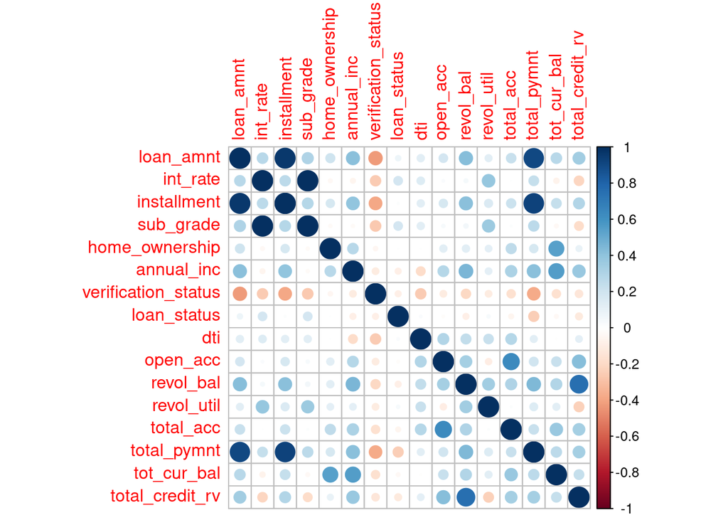

```r
#Check assumption
filtered_norm_samp_df_loan_matrix <-round(cor(filtered_norm_samp_df_loan),2)
corrplot(filtered_norm_samp_df_loan_matrix)
```

```r
KMO(filtered_norm_samp_df_loan)
```

```
## Kaiser-Meyer-Olkin factor adequacy
## Call: KMO(r = filtered_norm_samp_df_loan)
## Overall MSA =  0.66
## MSA for each item =
##           loan_amnt            int_rate         installment           sub_grade
##                0.77                0.58                0.81                0.59
##      home_ownership          annual_inc verification_status         loan_status
##                0.70                0.77                0.89                0.17
##                 dti            open_acc           revol_bal          revol_util
##                0.59                0.71                0.57                0.36
##           total_acc         total_pymnt         tot_cur_bal     total_credit_rv
##                0.77                0.73                0.73                0.54
```

There are some high correlation among the variables that shown in the graph.

The Kaiser-Meyer-Olkin (KMO) test is a standard to assess the suitability of a data set for PCA. You are looking for a KMO value of 0.5 or more. Here it is 0.66, so we are good.

```r
samp_loan_pca <- principal(filtered_norm_samp_df_loan, 16, rotate="none", weights=TRUE, scores=TRUE)
print(samp_loan_pca)
```

```
## Principal Components Analysis
## Call: principal(r = filtered_norm_samp_df_loan, nfactors = 16, rotate = "none",
##     scores = TRUE, weights = TRUE)
## Standardized loadings (pattern matrix) based upon correlation matrix
##                       PC1   PC2   PC3   PC4   PC5   PC6   PC7   PC8   PC9  PC10
## loan_amnt            0.85  0.19 -0.33 -0.17 -0.19 -0.06  0.06  0.17 -0.02  0.01
## int_rate             0.28  0.84  0.20  0.13 -0.01  0.21 -0.26 -0.08  0.16  0.05
## installment          0.84  0.20 -0.35 -0.18 -0.12 -0.10  0.02  0.22 -0.06 -0.01
## sub_grade            0.31  0.83  0.18  0.13 -0.03  0.22 -0.26 -0.09  0.17  0.07
## home_ownership       0.34 -0.22 -0.02  0.65 -0.13 -0.28  0.09  0.14  0.46 -0.21
## annual_inc           0.60 -0.34 -0.22  0.33  0.07  0.30 -0.09 -0.10 -0.32  0.14
## verification_status -0.49 -0.27 -0.07  0.15  0.24  0.26 -0.27  0.65  0.10  0.18
## loan_status         -0.06  0.28  0.17  0.15 -0.54  0.40  0.59  0.22 -0.10  0.00
## dti                  0.26  0.14  0.63 -0.28  0.13 -0.44  0.26  0.14  0.04  0.32
## open_acc             0.46 -0.32  0.59 -0.09 -0.21  0.11 -0.30  0.12 -0.10 -0.06
## revol_bal            0.69 -0.22  0.15 -0.14  0.46  0.32  0.26 -0.04  0.14 -0.07
## revol_util           0.25  0.45  0.15  0.36  0.63 -0.05  0.24  0.12 -0.25 -0.18
## total_acc            0.50 -0.32  0.53  0.11 -0.18 -0.10 -0.25  0.06 -0.21 -0.20
## total_pymnt          0.84  0.13 -0.36 -0.21  0.03 -0.19 -0.14  0.12 -0.01  0.00
## tot_cur_bal          0.51 -0.33 -0.01  0.62 -0.06 -0.09  0.05 -0.19  0.00  0.35
## total_credit_rv      0.54 -0.54  0.09 -0.36  0.08  0.34  0.10 -0.12  0.32  0.01
##                      PC11  PC12  PC13  PC14  PC15  PC16 h2       u2 com
## loan_amnt            0.02 -0.02  0.04 -0.06 -0.14  0.01  1 -2.2e-16 1.8
## int_rate             0.02  0.03 -0.01  0.00  0.02  0.08  1  0.0e+00 1.9
## installment          0.02 -0.03 -0.02 -0.09  0.12 -0.01  1 -3.1e-15 2.0
## sub_grade            0.03  0.04  0.01 -0.01 -0.01 -0.08  1 -8.9e-16 2.0
## home_ownership      -0.14  0.11  0.00  0.00  0.00  0.00  1  1.4e-15 4.0
## annual_inc          -0.20  0.30  0.01  0.00  0.01  0.00  1  1.0e-15 5.3
## verification_status  0.08  0.00  0.00  0.00 -0.01  0.00  1  1.3e-15 4.0
## loan_status          0.03 -0.01 -0.01  0.05  0.01  0.00  1 -4.4e-15 4.1
## dti                 -0.07  0.16  0.00  0.00  0.00  0.00  1  3.9e-15 4.5
## open_acc            -0.33 -0.23  0.00 -0.01  0.00  0.00  1  1.6e-15 5.0
## revol_bal            0.04 -0.02 -0.17 -0.01 -0.02  0.00  1 -1.8e-15 3.5
## revol_util          -0.02 -0.11  0.10  0.00  0.00  0.00  1  6.7e-16 4.5
## total_acc            0.36  0.13 -0.01  0.00  0.00  0.00  1  0.0e+00 5.5
## total_pymnt          0.01 -0.05 -0.02  0.16  0.01  0.00  1 -3.1e-15 1.9
## tot_cur_bal          0.16 -0.25  0.00  0.00  0.00  0.00  1  0.0e+00 4.1
## total_credit_rv      0.08  0.01  0.16  0.01  0.03  0.00  1 -1.1e-15 4.8
##
##                        PC1  PC2  PC3  PC4  PC5  PC6  PC7  PC8  PC9 PC10 PC11
## SS loadings           4.65 2.67 1.60 1.47 1.13 0.98 0.96 0.71 0.63 0.41 0.35
## Proportion Var        0.29 0.17 0.10 0.09 0.07 0.06 0.06 0.04 0.04 0.03 0.02
## Cumulative Var        0.29 0.46 0.56 0.65 0.72 0.78 0.84 0.89 0.93 0.95 0.97
## Proportion Explained  0.29 0.17 0.10 0.09 0.07 0.06 0.06 0.04 0.04 0.03 0.02
## Cumulative Proportion 0.29 0.46 0.56 0.65 0.72 0.78 0.84 0.89 0.93 0.95 0.97
##                       PC12 PC13 PC14 PC15 PC16
## SS loadings           0.28 0.07 0.04 0.04 0.01
## Proportion Var        0.02 0.00 0.00 0.00 0.00
## Cumulative Var        0.99 0.99 1.00 1.00 1.00
## Proportion Explained  0.02 0.00 0.00 0.00 0.00
## Cumulative Proportion 0.99 0.99 1.00 1.00 1.00
##
## Mean item complexity =  3.7
## Test of the hypothesis that 16 components are sufficient.
##
## The root mean square of the residuals (RMSR) is  0
##  with the empirical chi square  0  with prob <  NA
##
## Fit based upon off diagonal values = 1
```

```r
print.psych(samp_loan_pca, cut=0.3, sort=TRUE)
```

```
## Principal Components Analysis
## Call: principal(r = filtered_norm_samp_df_loan, nfactors = 16, rotate = "none",
##     scores = TRUE, weights = TRUE)
## Standardized loadings (pattern matrix) based upon correlation matrix
##                     item   PC1   PC2   PC3   PC4   PC5   PC6   PC7   PC8   PC9
## loan_amnt              1  0.85       -0.33
## total_pymnt           14  0.84       -0.36
## installment            3  0.84       -0.35
## revol_bal             11  0.69                    0.46  0.32
## annual_inc             6  0.60 -0.34        0.33        0.30             -0.32
## total_credit_rv       16  0.54 -0.54       -0.36        0.34              0.32
## int_rate               2        0.84
## sub_grade              4  0.31  0.83
## dti                    9              0.63             -0.44
## open_acc              10  0.46 -0.32  0.59
## total_acc             13  0.50 -0.32  0.53
## home_ownership         5  0.34              0.65                          0.46
## tot_cur_bal           15  0.51 -0.33        0.62
## revol_util            12        0.45        0.36  0.63
## loan_status            8                         -0.54  0.40  0.59
## verification_status    7 -0.49                                      0.65
##                      PC10  PC11  PC12  PC13  PC14  PC15  PC16 h2       u2 com
## loan_amnt                                                      1 -2.2e-16 1.8
## total_pymnt                                                    1 -3.1e-15 1.9
## installment                                                    1 -3.1e-15 2.0
## revol_bal                                                      1 -1.8e-15 3.5
## annual_inc                       0.30                          1  1.0e-15 5.3
## total_credit_rv                                                1 -1.1e-15 4.8
## int_rate                                                       1  0.0e+00 1.9
## sub_grade                                                      1 -8.9e-16 2.0
## dti                  0.32                                      1  3.9e-15 4.5
## open_acc                  -0.33                                1  1.6e-15 5.0
## total_acc                  0.36                                1  0.0e+00 5.5
## home_ownership                                                 1  1.4e-15 4.0
## tot_cur_bal          0.35                                      1  0.0e+00 4.1
## revol_util                                                     1  6.7e-16 4.5
## loan_status                                                    1 -4.4e-15 4.1
## verification_status                                            1  1.3e-15 4.0
##
##                        PC1  PC2  PC3  PC4  PC5  PC6  PC7  PC8  PC9 PC10 PC11
## SS loadings           4.65 2.67 1.60 1.47 1.13 0.98 0.96 0.71 0.63 0.41 0.35
## Proportion Var        0.29 0.17 0.10 0.09 0.07 0.06 0.06 0.04 0.04 0.03 0.02
## Cumulative Var        0.29 0.46 0.56 0.65 0.72 0.78 0.84 0.89 0.93 0.95 0.97
## Proportion Explained  0.29 0.17 0.10 0.09 0.07 0.06 0.06 0.04 0.04 0.03 0.02
## Cumulative Proportion 0.29 0.46 0.56 0.65 0.72 0.78 0.84 0.89 0.93 0.95 0.97
##                       PC12 PC13 PC14 PC15 PC16
## SS loadings           0.28 0.07 0.04 0.04 0.01
## Proportion Var        0.02 0.00 0.00 0.00 0.00
## Cumulative Var        0.99 0.99 1.00 1.00 1.00
## Proportion Explained  0.02 0.00 0.00 0.00 0.00
## Cumulative Proportion 0.99 0.99 1.00 1.00 1.00
##
## Mean item complexity =  3.7
## Test of the hypothesis that 16 components are sufficient.
##
## The root mean square of the residuals (RMSR) is  0
##  with the empirical chi square  0  with prob <  NA
##
## Fit based upon off diagonal values = 1
```

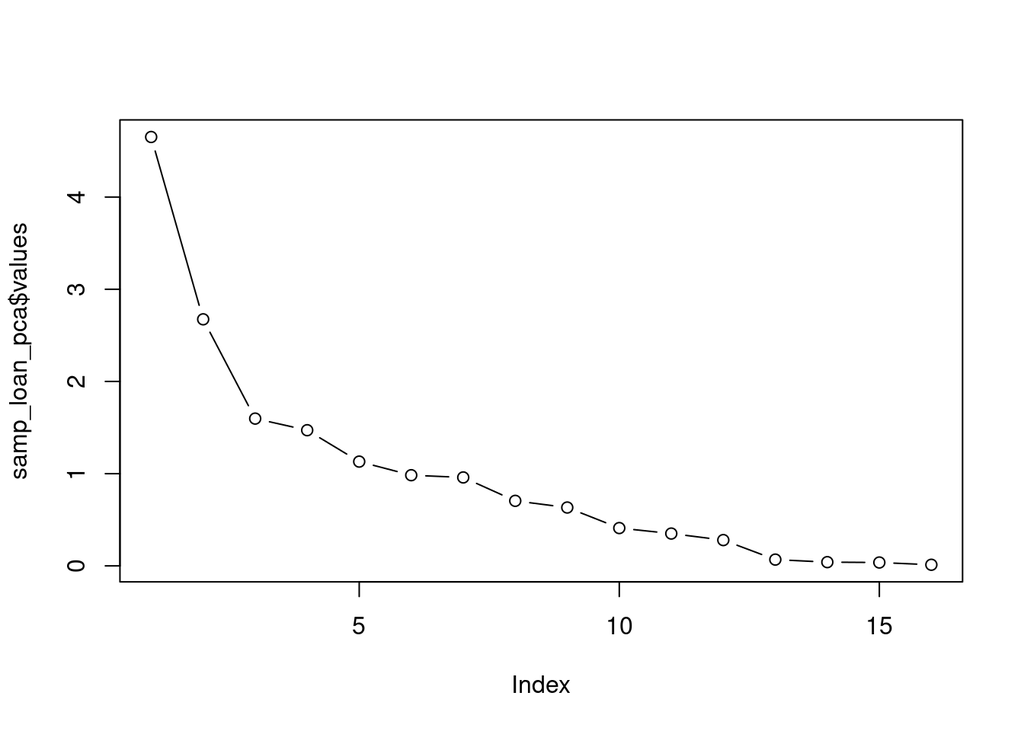

```r
plot(samp_loan_pca$values, type="b")
```

```r
samp_loan_pca$weights
```

```
##                             PC1         PC2          PC3         PC4
## loan_amnt            0.18355788  0.07022600 -0.207076777 -0.11323755
## int_rate             0.06033765  0.31547098  0.123358194  0.08583830
## installment          0.17990414  0.07513521 -0.218465387 -0.12480829
## sub_grade            0.06618005  0.31035908  0.112698253  0.08841581
## home_ownership       0.07372356 -0.08197796 -0.011092360  0.44513241
## annual_inc           0.12939296 -0.12624240 -0.138743282  0.22152531
## verification_status -0.10466278 -0.09930399 -0.043103384  0.10017887
## loan_status         -0.01253932  0.10525318  0.107314878  0.10168914
## dti                  0.05628835  0.05420114  0.394758063 -0.18890187
## open_acc             0.09848015 -0.12060119  0.367146074 -0.05845850
## revol_bal            0.14824277 -0.08155538  0.092827240 -0.09285058
## revol_util           0.05429309  0.16666156  0.092802901  0.24510985
## total_acc            0.10847190 -0.12011726  0.333922281  0.07406408
## total_pymnt          0.18066887  0.04939394 -0.228083560 -0.14368471
## tot_cur_bal          0.10890687 -0.12288773 -0.008683491  0.41879196
## total_credit_rv      0.11647217 -0.20022806  0.058143399 -0.24339829
##                              PC5         PC6         PC7         PC8
## loan_amnt           -0.167490033 -0.06144505  0.06718894  0.24136629
## int_rate            -0.008105928  0.21703074 -0.27259630 -0.10670720
## installment         -0.108520320 -0.10193956  0.02554843  0.31480819
## sub_grade           -0.023754599  0.22505335 -0.27275264 -0.12351183
## home_ownership      -0.112558236 -0.28616549  0.09644096  0.19353749
## annual_inc           0.061946905  0.30664147 -0.08993043 -0.14819138
## verification_status  0.212171398  0.26616373 -0.27792893  0.91948516
## loan_status         -0.480731582  0.40324469  0.61907781  0.30612773
## dti                  0.115166926 -0.44873095  0.27145087  0.19607566
## open_acc            -0.183291643  0.11631519 -0.30771184  0.16589909
## revol_bal            0.405672098  0.32306805  0.26895425 -0.05958901
## revol_util           0.554313729 -0.04711507  0.25018785  0.16977646
## total_acc           -0.157397765 -0.10468714 -0.26531875  0.09207827
## total_pymnt          0.025341296 -0.19015368 -0.15070058  0.16553177
## tot_cur_bal         -0.049649053 -0.09193557  0.05177805 -0.27182659
## total_credit_rv      0.068911675  0.34475730  0.10910082 -0.16652475
##                              PC9         PC10        PC11        PC12
## loan_amnt           -0.036094753  0.030665045  0.05545600 -0.05639048
## int_rate             0.254038004  0.112995726  0.04734538  0.10017354
## installment         -0.091789830 -0.032902849  0.06860934 -0.12165537
## sub_grade            0.262046772  0.180091551  0.07712592  0.15533605
## home_ownership       0.719932332 -0.504294520 -0.39976105  0.40623361
```

[output cut: 13 more lines]

```
## int_rate            -0.10131799  0.05514886  0.53745291  6.47222289
## installment         -0.25216913 -2.23903477  3.39199022 -0.63432215
## sub_grade            0.12736424 -0.15340980 -0.38091094 -6.40459549
## home_ownership      -0.04742993  0.07986662  0.07429244 -0.06300813
## annual_inc           0.16112678  0.09815234  0.17364440  0.16300299
## verification_status  0.01658588  0.03397551 -0.16375545  0.05253071
## loan_status         -0.07965555  1.19966315  0.30142942 -0.11165459
## dti                  0.06333548  0.05572236  0.07722908  0.07969191
## open_acc            -0.02259223 -0.13347921 -0.08954357 -0.15727917
## revol_bal           -2.50814751 -0.28864752 -0.55548496 -0.14849504
## revol_util           1.52234332  0.07249541  0.07395987 -0.08998312
## total_acc           -0.09373698  0.07067940 -0.08347465  0.02441323
## total_pymnt         -0.25944326  3.96880727  0.21978814 -0.28662995
## tot_cur_bal         -0.06893261 -0.10335798  0.09938355  0.13541380
## total_credit_rv      2.36286493  0.25721587  0.69950548  0.16361198
```

```r
sample_loan_updated <- samp_loan_pca$scores[,1:8]
```

Since our goal is to express the original variables via a new uncorrelated variables for further cluster analysis. Then we can keep all PCs that explain almost 90% of the information. In this case, will be the first 8 PCs.

# Factor Analysis

## PC extraction with Orthogonal rotation

```r
pcModel3q<-principal(filtered_norm_samp_df_loan, 3, rotate="quartimax")
print.psych(pcModel3q, cut=0.3, sort=TRUE)
```

```
## Principal Components Analysis
## Call: principal(r = filtered_norm_samp_df_loan, nfactors = 3, rotate = "quartimax")
## Standardized loadings (pattern matrix) based upon correlation matrix
##                     item   RC1   RC2   RC3   h2   u2 com
## total_pymnt           14  0.92             0.86 0.14 1.0
## loan_amnt              1  0.92             0.87 0.13 1.1
## installment            3  0.91             0.86 0.14 1.1
## annual_inc             6  0.62 -0.30       0.53 0.47 1.7
## revol_bal             11  0.53        0.51 0.54 0.46 2.0
## tot_cur_bal           15  0.44        0.34 0.36 0.64 2.5
## verification_status    7 -0.41 -0.34       0.31 0.69 2.3
## home_ownership         5  0.30             0.17 0.83 2.4
## int_rate               2        0.89       0.83 0.17 1.1
## sub_grade              4        0.88       0.82 0.18 1.1
## revol_util            12        0.50       0.28 0.72 1.3
## loan_status            8        0.31       0.11 0.89 1.3
## open_acc              10              0.80 0.66 0.34 1.0
## total_acc             13              0.78 0.64 0.36 1.1
## dti                    9        0.39  0.57 0.49 0.51 1.8
## total_credit_rv       16  0.41 -0.39  0.52 0.59 0.41 2.8
##
##                        RC1  RC2  RC3
## SS loadings           3.97 2.58 2.37
## Proportion Var        0.25 0.16 0.15
## Cumulative Var        0.25 0.41 0.56
## Proportion Explained  0.45 0.29 0.27
## Cumulative Proportion 0.45 0.73 1.00
##
## Mean item complexity =  1.6
## Test of the hypothesis that 3 components are sufficient.
##
## The root mean square of the residuals (RMSR) is  0.1
##  with the empirical chi square  1188.07  with prob <  8.6e-200
##
## Fit based upon off diagonal values = 0.89
```

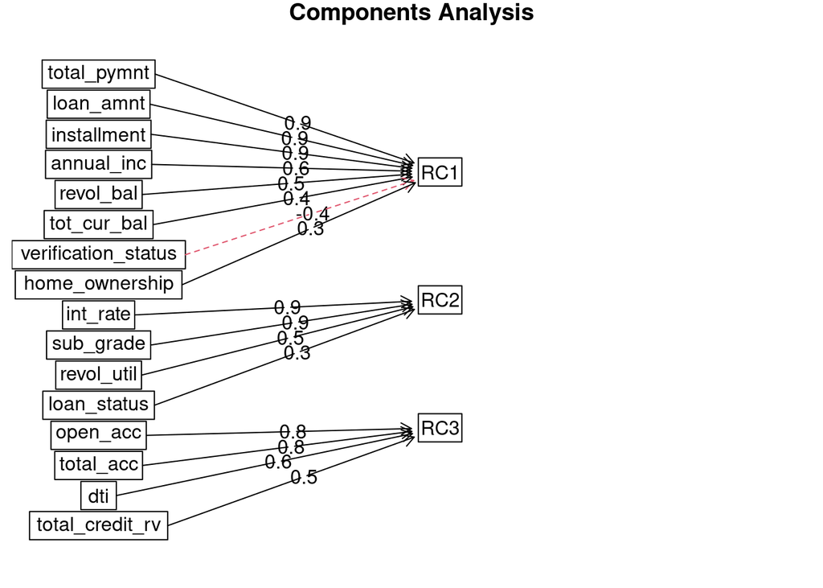

```r
fa.diagram(pcModel3q)
```

```r
pcModel4q<-principal(filtered_norm_samp_df_loan, 4, rotate="quartimax")
print.psych(pcModel4q, cut=0.3, sort=TRUE)
```

```
## Principal Components Analysis
## Call: principal(r = filtered_norm_samp_df_loan, nfactors = 4, rotate = "quartimax")
## Standardized loadings (pattern matrix) based upon correlation matrix
##                     item   RC1   RC2   RC3   RC4   h2    u2 com
## total_pymnt           14  0.94                   0.90 0.099 1.0
## installment            3  0.93                   0.90 0.104 1.1
## loan_amnt              1  0.93                   0.90 0.099 1.1
## revol_bal             11  0.53        0.50       0.56 0.436 2.2
## verification_status    7 -0.45                   0.33 0.666 2.2
## int_rate               2        0.90             0.85 0.155 1.1
## sub_grade              4        0.88             0.83 0.167 1.1
## revol_util            12        0.58             0.41 0.586 1.4
## loan_status            8        0.34             0.13 0.866 1.3
## open_acc              10              0.79       0.67 0.335 1.1
## total_acc             13              0.73  0.33 0.65 0.346 1.5
## dti                    9              0.65       0.56 0.436 1.7
## total_credit_rv       16  0.47 -0.46  0.53       0.72 0.283 2.9
## tot_cur_bal           15                    0.82 0.74 0.256 1.2
## home_ownership         5                    0.76 0.59 0.405 1.0
## annual_inc             6  0.47              0.60 0.63 0.369 2.2
##
##                        RC1  RC2  RC3  RC4
## SS loadings           3.75 2.53 2.20 1.92
## Proportion Var        0.23 0.16 0.14 0.12
## Cumulative Var        0.23 0.39 0.53 0.65
## Proportion Explained  0.36 0.24 0.21 0.19
## Cumulative Proportion 0.36 0.60 0.81 1.00
##
## Mean item complexity =  1.5
## Test of the hypothesis that 4 components are sufficient.
##
## The root mean square of the residuals (RMSR) is  0.09
##  with the empirical chi square  837.23  with prob <  2.9e-136
##
## Fit based upon off diagonal values = 0.92
```

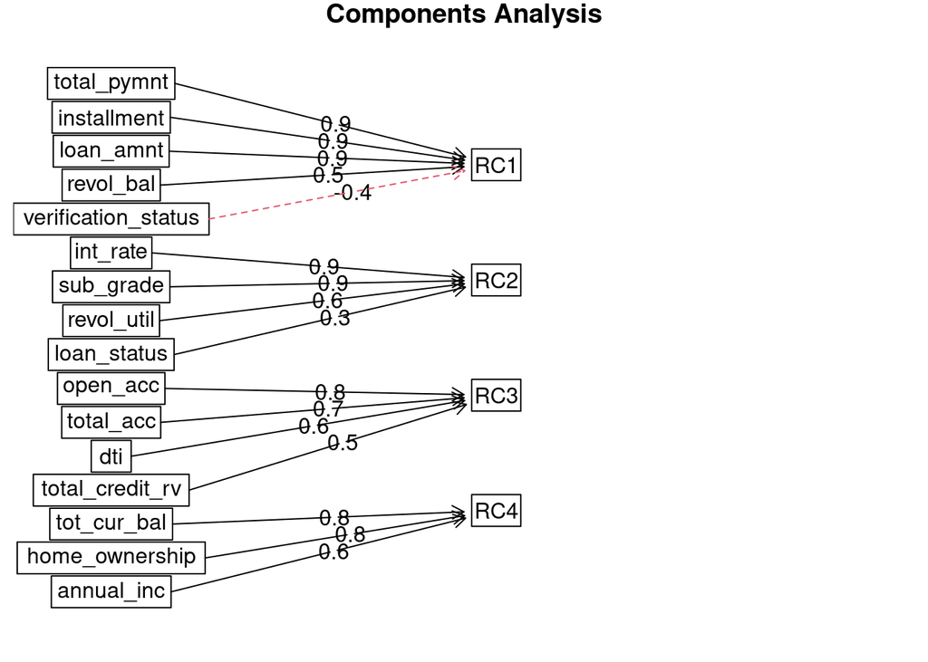

```r
fa.diagram(pcModel4q)
```

## PC extraction with Oblique rotation

```r
pcModel3o<-principal(filtered_norm_samp_df_loan, 3, rotate="oblimin")
print.psych(pcModel3o, cut=0.3, sort=TRUE)
```

```
## Principal Components Analysis
## Call: principal(r = filtered_norm_samp_df_loan, nfactors = 3, rotate = "oblimin")
## Standardized loadings (pattern matrix) based upon correlation matrix
##                     item   TC1   TC2   TC3   h2   u2 com
## total_pymnt           14  0.92             0.86 0.14 1.0
## loan_amnt              1  0.91             0.87 0.13 1.0
## installment            3  0.91             0.86 0.14 1.0
## annual_inc             6  0.62 -0.34       0.53 0.47 1.7
## tot_cur_bal           15  0.40        0.30 0.36 0.64 2.6
## verification_status    7 -0.35 -0.33       0.31 0.69 2.4
## home_ownership         5                   0.17 0.83 2.5
## int_rate               2        0.89       0.83 0.17 1.0
## sub_grade              4        0.87       0.82 0.18 1.1
## revol_util            12        0.50       0.28 0.72 1.2
## loan_status            8        0.32       0.11 0.89 1.5
## open_acc              10              0.82 0.66 0.34 1.0
## total_acc             13              0.79 0.64 0.36 1.0
## dti                    9        0.43  0.63 0.49 0.51 2.0
## revol_bal             11  0.44        0.48 0.54 0.46 2.0
## total_credit_rv       16  0.35 -0.39  0.48 0.59 0.41 2.8
##
##                        TC1  TC2  TC3
## SS loadings           3.84 2.60 2.49
## Proportion Var        0.24 0.16 0.16
## Cumulative Var        0.24 0.40 0.56
## Proportion Explained  0.43 0.29 0.28
## Cumulative Proportion 0.43 0.72 1.00
##
##  With component correlations of
##      TC1   TC2   TC3
## TC1 1.00  0.14  0.27
## TC2 0.14  1.00 -0.06
## TC3 0.27 -0.06  1.00
##
## Mean item complexity =  1.6
## Test of the hypothesis that 3 components are sufficient.
##
## The root mean square of the residuals (RMSR) is  0.1
##  with the empirical chi square  1188.07  with prob <  8.6e-200
##
## Fit based upon off diagonal values = 0.89
```

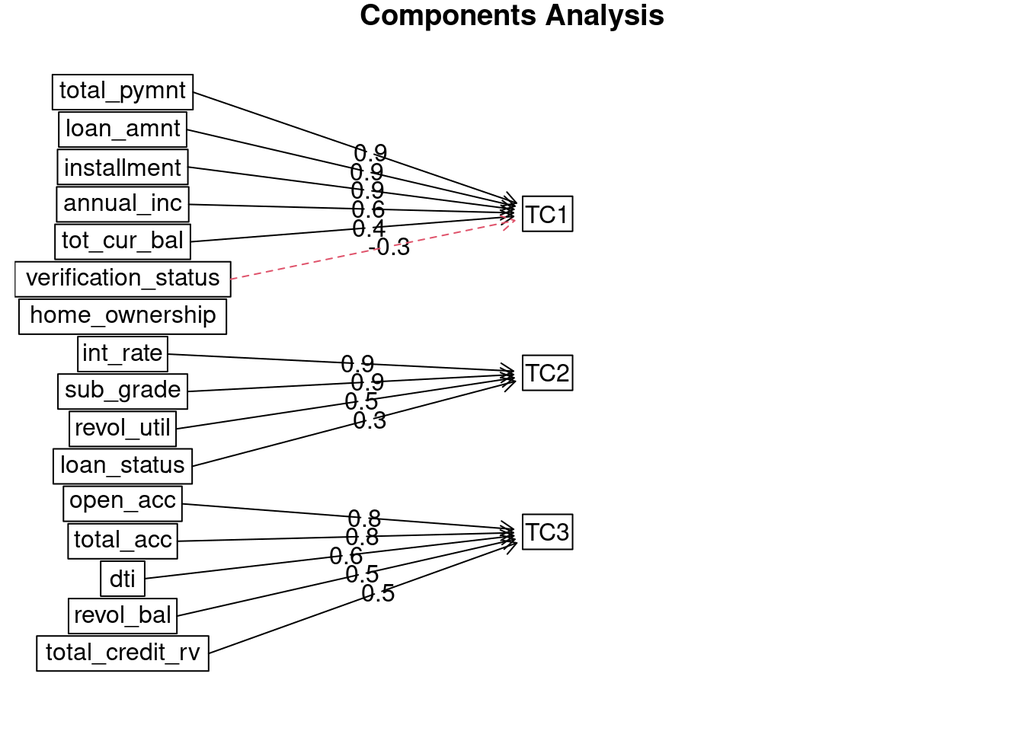

```r
fa.diagram(pcModel3o)
```

```r
pcModel4o<-principal(filtered_norm_samp_df_loan, 4, rotate="oblimin")
print.psych(pcModel4o, cut=0.3, sort=TRUE)
```

```
## Principal Components Analysis
## Call: principal(r = filtered_norm_samp_df_loan, nfactors = 4, rotate = "oblimin")
## Standardized loadings (pattern matrix) based upon correlation matrix
##                     item   TC1   TC2   TC3   TC4   h2    u2 com
## total_pymnt           14  0.95                   0.90 0.099 1.0
## installment            3  0.94                   0.90 0.104 1.0
## loan_amnt              1  0.93                   0.90 0.099 1.0
## verification_status    7 -0.41                   0.33 0.666 2.4
## int_rate               2        0.89             0.85 0.155 1.0
## sub_grade              4        0.88             0.83 0.167 1.1
## revol_util            12        0.61             0.41 0.586 1.4
## total_credit_rv       16  0.43 -0.50  0.49       0.72 0.283 3.0
## loan_status            8        0.35             0.13 0.866 1.6
## open_acc              10              0.80       0.67 0.335 1.0
## total_acc             13              0.72  0.31 0.65 0.346 1.4
## dti                    9              0.71       0.56 0.436 1.7
## revol_bal             11  0.44        0.46       0.56 0.436 2.2
## tot_cur_bal           15                    0.83 0.74 0.256 1.0
## home_ownership         5                    0.79 0.59 0.405 1.0
## annual_inc             6  0.38              0.59 0.63 0.369 1.9
##
##                        TC1  TC2  TC3  TC4
## SS loadings           3.56 2.53 2.27 2.03
## Proportion Var        0.22 0.16 0.14 0.13
## Cumulative Var        0.22 0.38 0.52 0.65
## Proportion Explained  0.34 0.24 0.22 0.20
## Cumulative Proportion 0.34 0.59 0.80 1.00
##
##  With component correlations of
##      TC1   TC2   TC3   TC4
## TC1 1.00  0.14  0.26  0.24
## TC2 0.14  1.00 -0.04 -0.10
## TC3 0.26 -0.04  1.00  0.18
## TC4 0.24 -0.10  0.18  1.00
##
## Mean item complexity =  1.5
## Test of the hypothesis that 4 components are sufficient.
##
## The root mean square of the residuals (RMSR) is  0.09
##  with the empirical chi square  837.23  with prob <  2.9e-136
##
## Fit based upon off diagonal values = 0.92
```

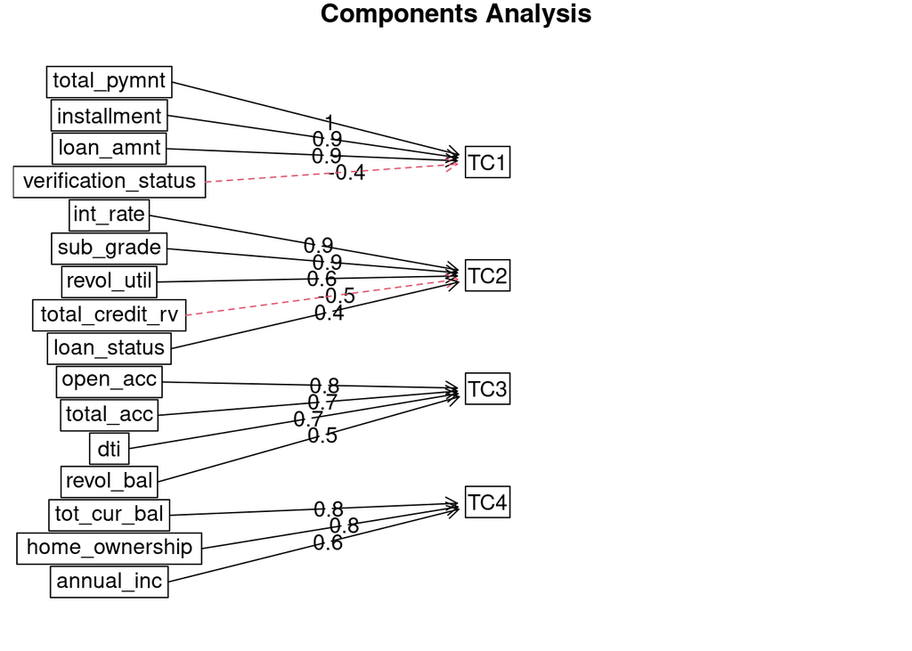

```r
fa.diagram(pcModel4o)
```

## Remove total_credit_rv and revol_bal

```r
fa_loan <- subset(filtered_norm_samp_df_loan, select = -c(total_credit_rv, revol_bal))
fa_loan_1 <- subset(filtered_norm_samp_df_loan_1, select = -c(total_credit_rv, revol_bal))
```

#Factor 4 PC oblique rotate

```r
pcModel4o1<-principal(fa_loan, 4, rotate="oblimin")
print.psych(pcModel4o1, cut=0.3, sort=TRUE)
```

```
## Principal Components Analysis
## Call: principal(r = fa_loan, nfactors = 4, rotate = "oblimin")
## Standardized loadings (pattern matrix) based upon correlation matrix
##                     item   TC1   TC2   TC4   TC3   h2    u2 com
## total_pymnt           13  0.98                   0.94 0.064 1.0
## installment            3  0.95                   0.93 0.075 1.0
## loan_amnt              1  0.94                   0.92 0.078 1.0
## verification_status    7 -0.43                   0.36 0.639 2.2
## int_rate               2        0.92             0.88 0.120 1.0
## sub_grade              4        0.91             0.87 0.130 1.0
## revol_util            11        0.64             0.42 0.583 1.5
## loan_status            8        0.40             0.16 0.837 1.7
## tot_cur_bal           14              0.83       0.74 0.256 1.0
## home_ownership         5              0.77       0.57 0.433 1.1
## annual_inc             6  0.35        0.63       0.63 0.370 1.7
## open_acc              10                    0.81 0.70 0.301 1.1
## total_acc             12                    0.77 0.74 0.259 1.2
## dti                    9             -0.33  0.71 0.59 0.407 1.6
##
##                        TC1  TC2  TC4  TC3
## SS loadings           3.19 2.38 2.00 1.87
## Proportion Var        0.23 0.17 0.14 0.13
## Cumulative Var        0.23 0.40 0.54 0.67
## Proportion Explained  0.34 0.25 0.21 0.20
## Cumulative Proportion 0.34 0.59 0.80 1.00
##
##  With component correlations of
##      TC1   TC2   TC4  TC3
## TC1 1.00  0.25  0.25 0.20
## TC2 0.25  1.00 -0.10 0.06
## TC4 0.25 -0.10  1.00 0.18
## TC3 0.20  0.06  0.18 1.00
##
## Mean item complexity =  1.3
## Test of the hypothesis that 4 components are sufficient.
##
## The root mean square of the residuals (RMSR) is  0.08
##  with the empirical chi square  556.39  with prob <  1.4e-91
##
## Fit based upon off diagonal values = 0.93
```

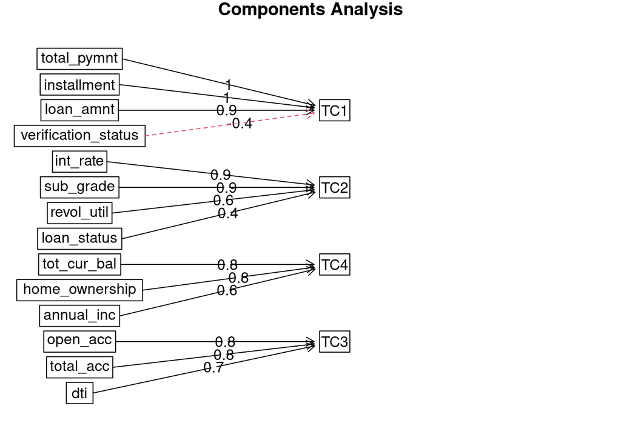

```r
fa.diagram(pcModel4o1)
```

```r
pcModel4o1_1<-principal(fa_loan_1, 4, rotate="oblimin")
print.psych(pcModel4o1_1, cut=0.3, sort=TRUE)
```

```
## Principal Components Analysis
## Call: principal(r = fa_loan_1, nfactors = 4, rotate = "oblimin")
## Standardized loadings (pattern matrix) based upon correlation matrix
##                     item   TC1   TC2   TC3   TC4   h2    u2 com
## total_pymnt           13  0.98                   0.94 0.056 1.0
## installment            3  0.94                   0.92 0.084 1.0
## loan_amnt              1  0.93                   0.93 0.067 1.0
## int_rate               2        0.90             0.86 0.137 1.0
## sub_grade              4        0.89             0.86 0.143 1.1
## revol_util            11        0.68             0.44 0.557 1.3
## loan_status            8        0.48             0.25 0.748 1.9
## verification_status    7                         0.24 0.760 3.1
## open_acc              10              0.86       0.76 0.245 1.0
## total_acc             12              0.79       0.74 0.263 1.1
## dti                    9              0.68       0.55 0.453 1.6
## tot_cur_bal           14                    0.85 0.79 0.211 1.0
## home_ownership         5                    0.81 0.62 0.383 1.1
## annual_inc             6  0.41              0.53 0.63 0.367 2.5
##
##                        TC1  TC2  TC3  TC4
## SS loadings           3.13 2.57 1.92 1.90
## Proportion Var        0.22 0.18 0.14 0.14
## Cumulative Var        0.22 0.41 0.54 0.68
## Proportion Explained  0.33 0.27 0.20 0.20
## Cumulative Proportion 0.33 0.60 0.80 1.00
##
##  With component correlations of
##      TC1   TC2  TC3   TC4
## TC1 1.00  0.17 0.19  0.22
## TC2 0.17  1.00 0.03 -0.13
## TC3 0.19  0.03 1.00  0.20
## TC4 0.22 -0.13 0.20  1.00
##
## Mean item complexity =  1.4
## Test of the hypothesis that 4 components are sufficient.
##
## The root mean square of the residuals (RMSR) is  0.08
##  with the empirical chi square  521.37  with prob <  1.6e-84
##
## Fit based upon off diagonal values = 0.93
```

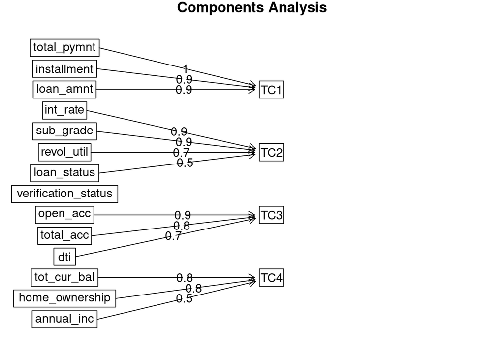

```r
fa.diagram(pcModel4o1_1)
```

```r
pcModel4q1<-principal(fa_loan, 4, rotate="quartimax")
print.psych(pcModel4q1, cut=0.3, sort=TRUE)
```

```
## Principal Components Analysis
## Call: principal(r = fa_loan, nfactors = 4, rotate = "quartimax")
## Standardized loadings (pattern matrix) based upon correlation matrix
##                     item   RC1   RC2   RC4   RC3   h2    u2 com
## total_pymnt           13  0.96                   0.94 0.064 1.0
## installment            3  0.95                   0.93 0.075 1.1
## loan_amnt              1  0.94                   0.92 0.078 1.1
## verification_status    7 -0.47                   0.36 0.639 2.2
## int_rate               2        0.92             0.88 0.120 1.1
## sub_grade              4        0.91             0.87 0.130 1.1
## revol_util            11        0.60             0.42 0.583 1.3
## loan_status            8        0.37             0.16 0.837 1.4
## tot_cur_bal           14              0.82       0.74 0.256 1.2
## home_ownership         5              0.74       0.57 0.433 1.1
## annual_inc             6  0.43        0.65       0.63 0.370 1.9
## open_acc              10                    0.81 0.70 0.301 1.2
## total_acc             12              0.33  0.78 0.74 0.259 1.4
## dti                    9                    0.68 0.59 0.407 1.6
##
##                        RC1  RC2  RC4  RC3
## SS loadings           3.32 2.36 1.94 1.83
## Proportion Var        0.24 0.17 0.14 0.13
## Cumulative Var        0.24 0.41 0.54 0.67
## Proportion Explained  0.35 0.25 0.21 0.19
## Cumulative Proportion 0.35 0.60 0.81 1.00
##
## Mean item complexity =  1.3
## Test of the hypothesis that 4 components are sufficient.
##
## The root mean square of the residuals (RMSR) is  0.08
##  with the empirical chi square  556.39  with prob <  1.4e-91
##
## Fit based upon off diagonal values = 0.93
```

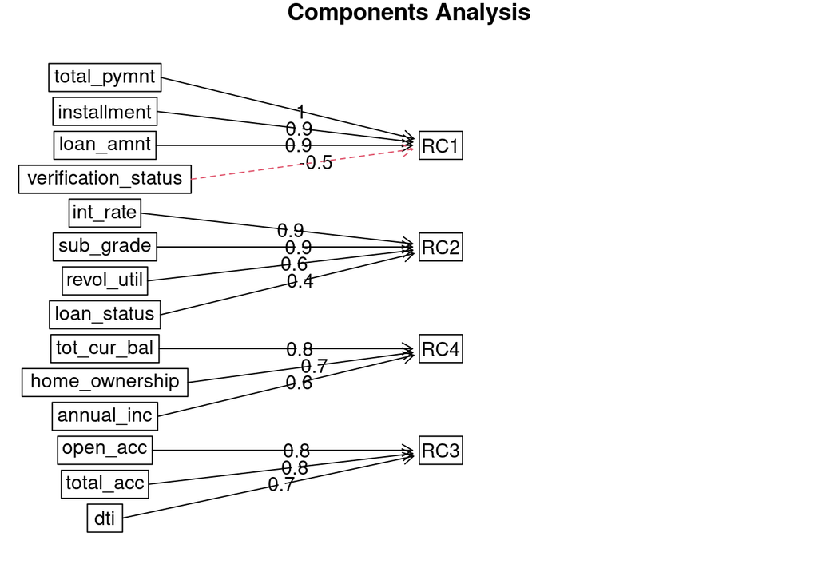

```r
fa.diagram(pcModel4q1)
```

```r
pcModel4q1_1<-principal(fa_loan_1, 4, rotate="quartimax")
print.psych(pcModel4q1_1, cut=0.3, sort=TRUE)
```

```
## Principal Components Analysis
## Call: principal(r = fa_loan_1, nfactors = 4, rotate = "quartimax")
## Standardized loadings (pattern matrix) based upon correlation matrix
##                     item   RC1   RC2   RC3   RC4   h2    u2 com
## total_pymnt           13  0.97                   0.94 0.056 1.0
## loan_amnt              1  0.95                   0.93 0.067 1.1
## installment            3  0.94                   0.92 0.084 1.1
## verification_status    7 -0.31                   0.24 0.760 3.2
## int_rate               2        0.90             0.86 0.137 1.1
## sub_grade              4        0.89             0.86 0.143 1.1
## revol_util            11        0.64             0.44 0.557 1.2
## loan_status            8        0.44             0.25 0.748 1.6
## open_acc              10              0.85       0.76 0.245 1.1
## total_acc             12              0.80       0.74 0.263 1.3
## dti                    9        0.31  0.65       0.55 0.453 1.6
## tot_cur_bal           14                    0.84 0.79 0.211 1.2
## home_ownership         5                    0.78 0.62 0.383 1.0
## annual_inc             6  0.47              0.56 0.63 0.367 2.6
##
##                        RC1  RC2  RC3  RC4
## SS loadings           3.23 2.56 1.88 1.85
## Proportion Var        0.23 0.18 0.13 0.13
## Cumulative Var        0.23 0.41 0.55 0.68
## Proportion Explained  0.34 0.27 0.20 0.19
## Cumulative Proportion 0.34 0.61 0.81 1.00
##
## Mean item complexity =  1.4
## Test of the hypothesis that 4 components are sufficient.
##
## The root mean square of the residuals (RMSR) is  0.08
##  with the empirical chi square  521.37  with prob <  1.6e-84
##
## Fit based upon off diagonal values = 0.93
```

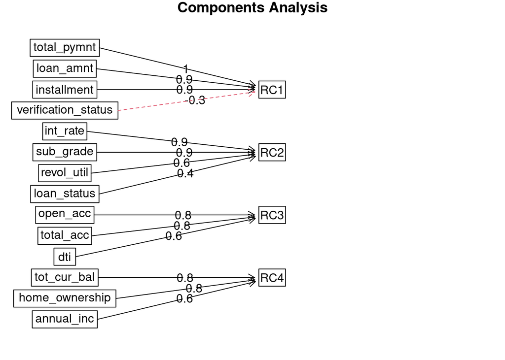

```r
fa.diagram(pcModel4q1_1)
```

```r
pcModel4o1 <-principal(fa_loan, 4, rotate="oblimin", scores=TRUE)
fscores <- pcModel4o1$scores
describe(fscores)
```

```
##     vars   n mean sd median trimmed  mad   min  max range skew kurtosis   se
## TC1    1 475    0  1  -0.13   -0.07 1.03 -1.95 3.47  5.42 0.70     0.34 0.05
## TC2    2 475    0  1   0.01   -0.02 0.92 -2.34 2.72  5.06 0.14    -0.19 0.05
## TC4    3 475    0  1  -0.16   -0.06 1.04 -2.10 3.50  5.59 0.55     0.06 0.05
## TC3    4 475    0  1  -0.10   -0.04 1.01 -2.26 2.45  4.71 0.32    -0.44 0.05
```

```r
FscoresMatrix<-cor(fscores)
print(FscoresMatrix)
```

```
##           TC1         TC2        TC4        TC3
## TC1 1.0000000  0.24574044  0.2489941 0.20303992
## TC2 0.2457404  1.00000000 -0.1013043 0.05713298
## TC4 0.2489941 -0.10130432  1.0000000 0.17651429
## TC3 0.2030399  0.05713298  0.1765143 1.00000000
```

```r
head(fscores, 10)
```

```
##            TC1        TC2         TC4        TC3
## 1   1.59455549  0.1734580  1.16706881  1.8819266
## 3  -0.79336029 -0.8412290  0.04721386  0.1896537
## 4   0.02120393  0.7899532 -1.13951072 -1.0166855
## 5   1.71274170  0.4307981  1.10257965 -0.3655306
## 6  -1.16084450  1.0439448 -1.07395169 -0.9716197
## 7  -1.19452301 -0.4306024 -1.55496943 -0.8867857
## 8  -0.25996726  0.9991328 -1.44352744 -0.3107876
## 9   0.94035741 -1.1894674  0.96070107  0.5026319
## 10 -0.21777187  1.8920984  0.11322906  1.1439072
## 11 -0.73570614 -1.0178774  0.50208210 -0.2536642
```

```r
lowerCor(fscores)
```

```
##     TC1   TC2   TC4   TC3
## TC1  1.00
## TC2  0.25  1.00
## TC4  0.25 -0.10  1.00
## TC3  0.20  0.06  0.18  1.00
```

## Cluster Analysis of sampling set.seed(99) - 500 Samples

# perform hierarchical clustering using several different methods

```r
# Define linkage methods

m <- c( "average", "single", "complete", "ward")
names(m) <- c( "average", "single", "complete", "ward")
```

```r
# Function to compute agglomerative coefficient

ac <- function(x) {
agnes(fscores, method = x)$ac
}
```

```r
# Calculate agglomerative coefficient for each clustering linkage method

sapply(m, ac)
```

```
##   average    single  complete      ward
## 0.8451020 0.6941339 0.9199687 0.9764011
```

```r
# We can see that Ward’s minimum variance method produces the highest agglomerative coefficient, thus we’ll use that as the method for our final hierarchical clustering
```

```r
# calculate gap statistic for each number of clusters (up to 10 clusters)

gap_stat_h <- clusGap(fscores, FUN = hcut, nstart = 25, K.max = 10, B = 50)

gap_stat_k <- clusGap(fscores, FUN = kmeans, nstart = 25, K.max = 10, B = 50)
```

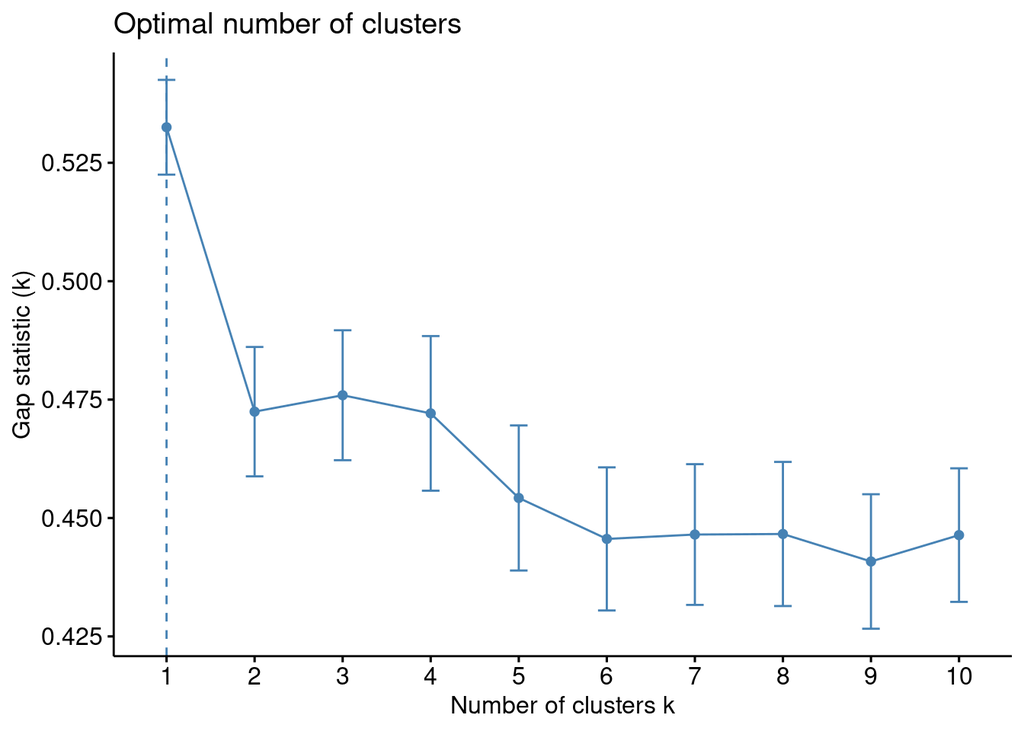

```r
# produce plot of clusters vs. gap statistic

fviz_gap_stat(gap_stat_h)
```

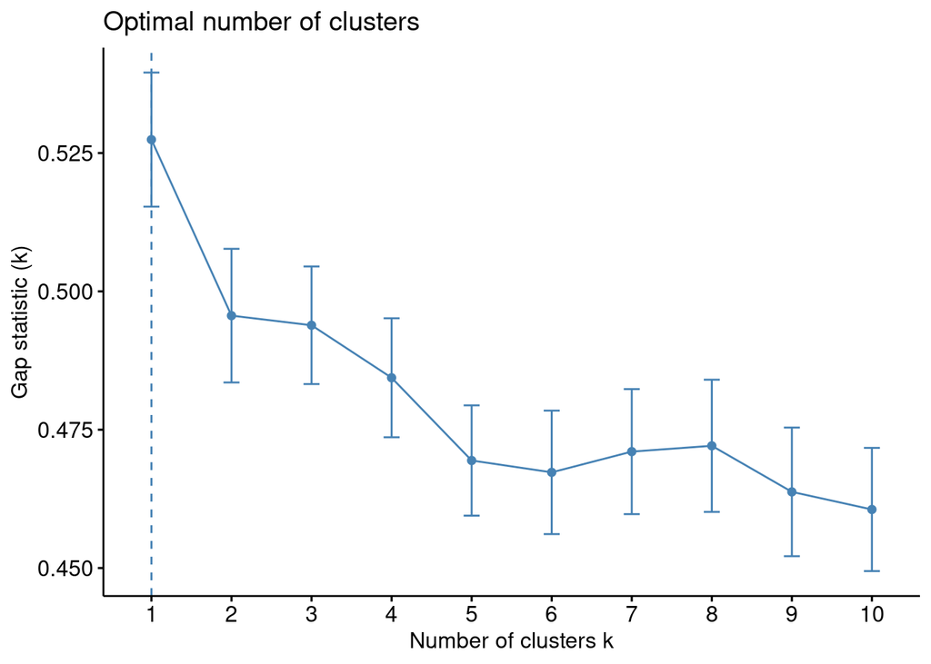

```r
fviz_gap_stat(gap_stat_k)
```

```r
# Finding distance matrix using 3 different distance

distance_mat1 <- dist(fscores, method = 'euclidean')
distance_mat2 <- dist(fscores, method = 'maximum')
distance_mat3 <- dist(fscores, method = 'manhattan')
```

```r
# Fitting Hierarchical clustering Model to dataset

set.seed(99)  # Setting seed
Hierar_cl_eu <- hclust(distance_mat1, method = "ward")
```

```
## The "ward" method has been renamed to "ward.D"; note new "ward.D2"
```

```r
Hierar_cl_max <- hclust(distance_mat2, method = "ward")
```

```
## The "ward" method has been renamed to "ward.D"; note new "ward.D2"
```

```r
Hierar_cl_man <- hclust(distance_mat3, method = "ward")
```

```
## The "ward" method has been renamed to "ward.D"; note new "ward.D2"
```

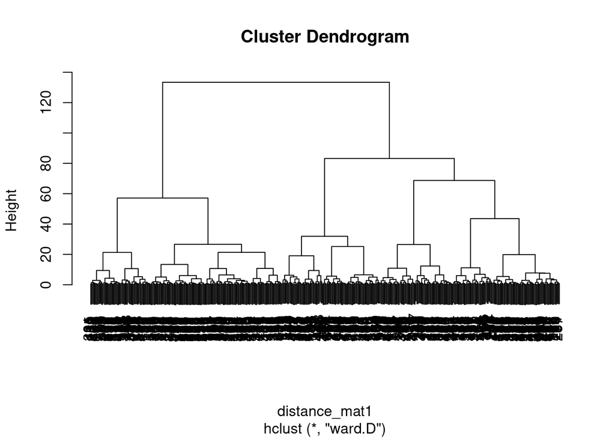

```r
# Plotting dendrogram

plot(Hierar_cl_eu)
```

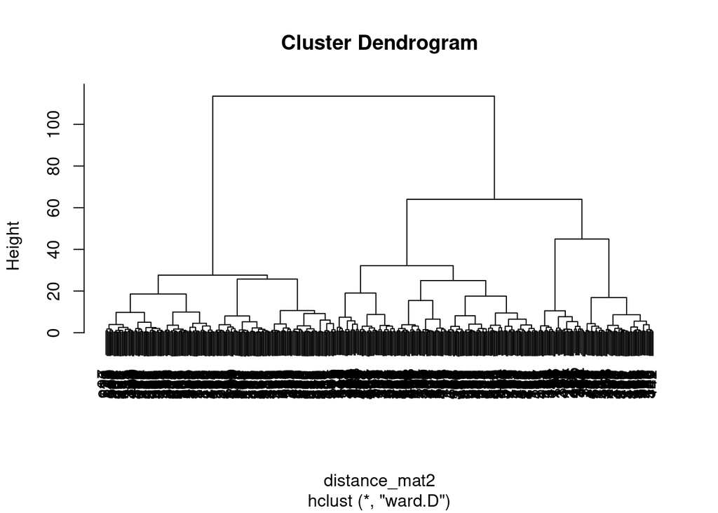

```r
plot(Hierar_cl_max)
```

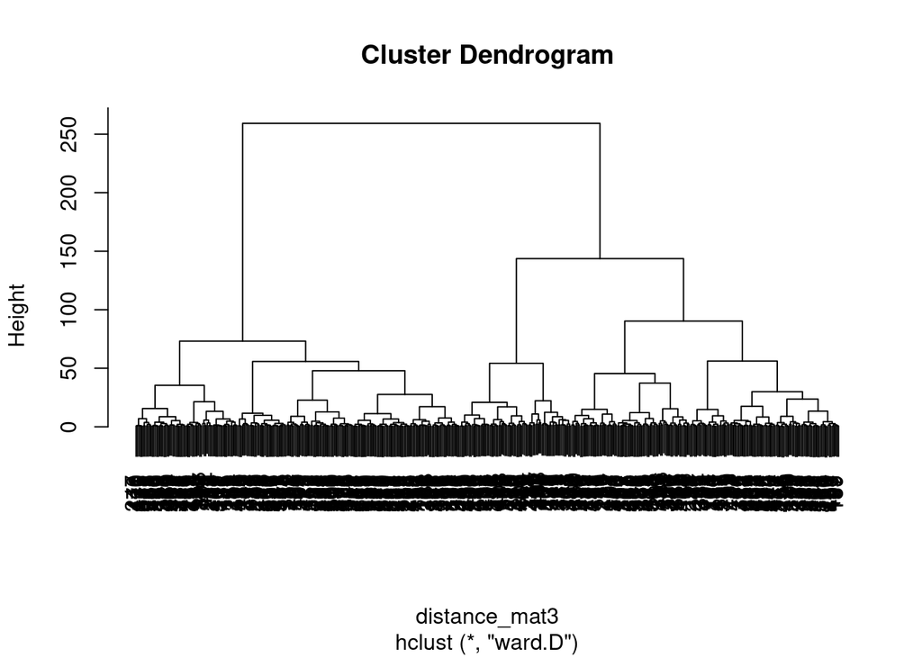

```r
plot(Hierar_cl_man)
```

```r
#suggest 4 group
```

# 3 Clusters - 500 samples

Hierarchical Euclidean

```r
# Cutting tree by no. of clusters
fit_3_eu <- cutree(Hierar_cl_eu, k = 3 )
fit_3_eu
```

```
##   1   3   4   5   6   7   8   9  10  11  12  13  14  15  16  17  18  19  20  21
##   1   2   2   1   2   2   2   3   1   2   3   1   3   3   2   3   2   1   3   2
##  22  23  24  26  27  28  29  30  31  32  33  34  35  36  37  38  39  40  41  42
##   2   1   3   3   3   2   1   2   2   2   3   3   2   2   3   2   2   3   2   2
##  43  44  45  47  48  49  50  51  52  53  54  55  56  57  58  59  60  61  62  63
##   3   1   2   2   1   2   3   2   2   2   2   3   3   1   2   2   2   3   3   2
##  64  65  66  67  68  69  70  71  72  73  74  75  76  78  79  80  81  82  83  84
##   3   3   1   2   2   1   1   1   3   3   3   2   2   3   2   3   3   1   1   3
##  85  86  87  88  89  90  91  92  93  94  95  96  97  98  99 101 102 103 104 105
##   3   2   3   2   2   3   3   3   1   3   2   2   2   3   2   2   3   2   3   2
## 106 107 108 109 110 111 112 113 114 115 116 117 119 120 121 122 123 124 125 126
##   3   3   3   1   2   2   1   1   2   2   2   2   2   2   3   3   3   2   3   1
## 127 128 129 130 131 132 133 134 135 136 137 138 140 141 142 143 144 145 146 147
##   3   3   1   3   2   2   2   2   3   3   3   3   3   1   1   3   1   2   3   2
## 148 149 150 151 152 153 154 155 156 157 158 159 160 161 162 163 164 165 166 167
```

[output cut: 33 more lines]

```r
# Find number of observations in each cluster
table(fit_3_eu)
```

```
## fit_3_eu
##   1   2   3
##  99 194 182
```

```r
# Append cluster labels to original data
final_data_3_eu <- cbind(fscores, cluster = fit_3_eu)

# Display first six rows of final data
head(final_data_3_eu)
```

```
##           TC1        TC2         TC4        TC3 cluster
## 1  1.59455549  0.1734580  1.16706881  1.8819266       1
## 3 -0.79336029 -0.8412290  0.04721386  0.1896537       2
## 4  0.02120393  0.7899532 -1.13951072 -1.0166855       2
## 5  1.71274170  0.4307981  1.10257965 -0.3655306       1
## 6 -1.16084450  1.0439448 -1.07395169 -0.9716197       2
## 7 -1.19452301 -0.4306024 -1.55496943 -0.8867857       2
```

```r
# Find mean values for each cluster
hcentres_3_eu <-aggregate(x=final_data_3_eu, by=list(cluster=fit_3_eu), FUN="mean")
print(hcentres_3_eu)
```

```
##   cluster        TC1         TC2          TC4        TC3 cluster
## 1       1  1.2547242  0.64519634 -0.007289228  0.6892253       1
## 2       2 -0.4767061 -0.07114695 -0.638394094 -0.6360131       2
## 3       3 -0.1743775 -0.27512049  0.684451032  0.3030398       3
```

Hierarchical Maximum

```r
# Cutting tree by no. of clusters
fit_3_max <- cutree(Hierar_cl_max, k = 3 )
fit_3_max
```

```
##   1   3   4   5   6   7   8   9  10  11  12  13  14  15  16  17  18  19  20  21
##   1   2   2   3   2   2   1   3   1   2   2   1   3   2   2   3   1   1   3   2
##  22  23  24  26  27  28  29  30  31  32  33  34  35  36  37  38  39  40  41  42
##   2   1   1   2   3   2   1   2   2   1   3   3   1   3   3   1   2   2   2   1
##  43  44  45  47  48  49  50  51  52  53  54  55  56  57  58  59  60  61  62  63
##   3   1   2   1   1   2   3   2   2   1   2   2   2   1   2   2   2   3   1   2
##  64  65  66  67  68  69  70  71  72  73  74  75  76  78  79  80  81  82  83  84
##   3   3   1   1   1   1   1   1   3   3   3   2   2   3   1   2   3   1   1   1
##  85  86  87  88  89  90  91  92  93  94  95  96  97  98  99 101 102 103 104 105
##   3   2   3   1   1   3   3   2   1   3   2   2   2   2   2   2   3   1   2   2
## 106 107 108 109 110 111 112 113 114 115 116 117 119 120 121 122 123 124 125 126
##   1   3   3   1   2   2   1   1   2   2   3   2   2   2   3   1   1   2   1   1
## 127 128 129 130 131 132 133 134 135 136 137 138 140 141 142 143 144 145 146 147
##   2   2   1   1   1   2   2   2   1   3   2   2   3   1   1   3   1   2   3   2
## 148 149 150 151 152 153 154 155 156 157 158 159 160 161 162 163 164 165 166 167
```

[output cut: 33 more lines]

```r
# Find number of observations in each cluster
table(fit_3_max)
```

```
## fit_3_max
##   1   2   3
## 175 200 100
```

```r
# Append cluster labels to original data
final_data_3_max <- cbind(fscores, cluster = fit_3_max)

# Display first six rows of final data
head(final_data_3_max)
```

```
##           TC1        TC2         TC4        TC3 cluster
## 1  1.59455549  0.1734580  1.16706881  1.8819266       1
## 3 -0.79336029 -0.8412290  0.04721386  0.1896537       2
## 4  0.02120393  0.7899532 -1.13951072 -1.0166855       2
## 5  1.71274170  0.4307981  1.10257965 -0.3655306       3
## 6 -1.16084450  1.0439448 -1.07395169 -0.9716197       2
## 7 -1.19452301 -0.4306024 -1.55496943 -0.8867857       2
```

```r
# Find mean values for each cluster
hcentres_3_max <-aggregate(x=final_data_3_max, by=list(cluster=fit_3_max), FUN="mean")
print(hcentres_3_max)
```

```
##   cluster         TC1        TC2         TC4        TC3 cluster
## 1       1  0.71932150  0.7867371 -0.08681345  0.3555512       1
## 2       2 -0.61929231 -0.3283924 -0.31522888 -0.6870005       2
## 3       3 -0.02022799 -0.7200052  0.78238130  0.7517864       3
```

Hierarchical Manhattan

```r
# Cutting tree by no. of clusters
fit_3_man <- cutree(Hierar_cl_man, k = 3 )
fit_3_man
```

```
##   1   3   4   5   6   7   8   9  10  11  12  13  14  15  16  17  18  19  20  21
##   1   2   2   1   2   2   2   1   3   2   2   1   1   2   2   1   2   3   1   2
##  22  23  24  26  27  28  29  30  31  32  33  34  35  36  37  38  39  40  41  42
##   2   1   2   2   1   2   3   2   2   3   1   1   1   1   1   2   2   1   2   3
##  43  44  45  47  48  49  50  51  52  53  54  55  56  57  58  59  60  61  62  63
##   1   1   2   3   3   2   1   2   2   2   2   2   1   1   2   2   2   1   2   2
##  64  65  66  67  68  69  70  71  72  73  74  75  76  78  79  80  81  82  83  84
##   1   1   1   3   2   1   1   1   1   1   1   2   2   1   2   2   1   3   3   3
##  85  86  87  88  89  90  91  92  93  94  95  96  97  98  99 101 102 103 104 105
##   1   2   1   2   3   1   1   2   1   1   2   2   1   2   2   2   1   2   1   2
## 106 107 108 109 110 111 112 113 114 115 116 117 119 120 121 122 123 124 125 126
##   2   3   1   1   2   2   3   3   2   2   1   2   2   2   1   2   1   2   2   3
## 127 128 129 130 131 132 133 134 135 136 137 138 140 141 142 143 144 145 146 147
##   2   2   3   2   2   2   2   2   1   1   2   2   1   1   3   1   3   2   1   2
## 148 149 150 151 152 153 154 155 156 157 158 159 160 161 162 163 164 165 166 167
```

[output cut: 33 more lines]

```r
# Find number of observations in each cluster
table(fit_3_man)
```

```
## fit_3_man
##   1   2   3
## 181 219  75
```

```r
# Append cluster labels to original data
final_data_3_man <- cbind(fscores, cluster = fit_3_man)

# Display first six rows of final data
head(final_data_3_man)
```

```
##           TC1        TC2         TC4        TC3 cluster
## 1  1.59455549  0.1734580  1.16706881  1.8819266       1
## 3 -0.79336029 -0.8412290  0.04721386  0.1896537       2
## 4  0.02120393  0.7899532 -1.13951072 -1.0166855       2
## 5  1.71274170  0.4307981  1.10257965 -0.3655306       1
## 6 -1.16084450  1.0439448 -1.07395169 -0.9716197       2
## 7 -1.19452301 -0.4306024 -1.55496943 -0.8867857       2
```

```r
# Find mean values for each cluster
hcentres_3_man <-aggregate(x=final_data_3_man, by=list(cluster=fit_3_man), FUN="mean")
print(hcentres_3_man)
```

```
##   cluster        TC1         TC2         TC4        TC3 cluster
## 1       1  0.2850035 -0.46500110  0.45746177  0.5504145       1
## 2       2 -0.6141576 -0.09040738 -0.40880739 -0.6241886       2
## 3       3  1.1055317  1.38619222  0.08970985  0.4942971       3
```

K-mean (Non-Hierarchical)

```r
# Kmeans clustering

set.seed(99)
k_cl3 <- kmeans(fscores,3,nstart=25)
k_cl3
```

```
## K-means clustering with 3 clusters of sizes 143, 131, 201
##
## Cluster means:
##           TC1         TC2         TC4        TC3
## 1 -0.08338865 -0.72972613  0.77409412  0.5783135
## 2  1.02158691  0.94978049  0.07928446  0.3662194
## 3 -0.60648412 -0.09985277 -0.60239663 -0.6501173
##
## Clustering vector:
##   1   3   4   5   6   7   8   9  10  11  12  13  14  15  16  17  18  19  20  21
##   2   1   3   2   3   3   3   1   2   1   3   1   1   3   3   3   3   2   1   3
##  22  23  24  26  27  28  29  30  31  32  33  34  35  36  37  38  39  40  41  42
##   3   2   3   1   1   3   2   3   3   2   1   1   1   1   1   2   3   1   3   2
##  43  44  45  47  48  49  50  51  52  53  54  55  56  57  58  59  60  61  62  63
##   1   2   3   2   2   3   1   3   1   3   3   3   1   2   3   3   3   1   3   3
```

[output cut: 51 more lines]

## Cluster Analysis of 100 samples from filtered_norm_samp_df_loan to validate - Internal Validation

# Random sampling

```r
# Set the seed for reproducibility
set.seed(85)

# Perform random sampling
validate_indices <- sample(nrow(fa_loan), 100)  # Sample 100 rows without replacement
validate_samp_df_loan <- fa_loan[validate_indices, ]
```

```r
validate_pcModel4o1 <-principal(validate_samp_df_loan, 4, rotate="oblimin", scores=TRUE)
validate_fscores <- validate_pcModel4o1$scores

describe(validate_fscores)
```

```
##     vars   n mean sd median trimmed  mad   min  max range skew kurtosis  se
## TC1    1 100    0  1  -0.17   -0.09 1.00 -1.72 3.03  4.75 0.84     0.40 0.1
## TC2    2 100    0  1   0.01    0.00 0.85 -2.23 2.73  4.96 0.14     0.27 0.1
## TC4    3 100    0  1  -0.08   -0.02 1.18 -2.05 2.52  4.57 0.21    -0.81 0.1
## TC3    4 100    0  1  -0.08   -0.06 0.91 -2.08 2.63  4.71 0.54     0.12 0.1
```

```r
validate_FscoresMatrix <- cor(validate_fscores)
print(validate_FscoresMatrix)
```

```
##           TC1         TC2         TC4        TC3
## TC1 1.0000000  0.15659155  0.35558414 0.14242161
## TC2 0.1565916  1.00000000 -0.02977028 0.11166052
## TC4 0.3555841 -0.02977028  1.00000000 0.01119011
## TC3 0.1424216  0.11166052  0.01119011 1.00000000
```

```r
head(validate_fscores, 10)
```

```
##             TC1         TC2        TC4        TC3
## 144  1.41729219  1.32123259 -0.8073526  0.1963357
## 20  -0.02834488 -0.63367814  1.2710286  2.3026561
## 362 -0.46602092  0.27072708  0.2654087 -1.2501171
## 429 -0.38414276  0.17384041 -0.7936397  0.5375001
## 288 -0.36120597 -0.13452097  0.9946053 -0.6622895
## 95  -1.04562855 -1.02483069 -1.0040383 -0.2845974
## 266  0.64918961 -0.01900662  0.8309439 -0.2772467
## 154  3.03164843  0.00351034 -0.1839728  0.6684619
## 416  0.83842788  2.13318472  1.2482877 -0.6251046
## 343  0.04596336 -0.55857534 -0.9633859 -0.8995807
```

```r
lowerCor(validate_fscores)
```

```
##     TC1   TC2   TC4   TC3
## TC1  1.00
## TC2  0.16  1.00
## TC4  0.36 -0.03  1.00
## TC3  0.14  0.11  0.01  1.00
```

```r
# Define linkage methods

m <- c( "average", "single", "complete", "ward")
names(m) <- c( "average", "single", "complete", "ward")
```

```r
# Function to compute agglomerative coefficient

ac <- function(x) {
agnes(validate_fscores, method = x)$ac
}
```

```r
# Calculate agglomerative coefficient for each clustering linkage method

sapply(m, ac)
```

```
##   average    single  complete      ward
## 0.7309522 0.5867379 0.8441239 0.9215096
```

```r
# We can see that Ward’s minimum variance method produces the highest agglomerative coefficient, thus we’ll use that as the method for our final hierarchical clustering
```

```r
# calculate gap statistic for each number of clusters (up to 10 clusters)

validate_gap_stat_h <- clusGap(validate_fscores, FUN = hcut, nstart = 25, K.max = 10, B = 50)

validate_gap_stat_k <- clusGap(validate_fscores, FUN = kmeans, nstart = 25, K.max = 10, B = 50)
```

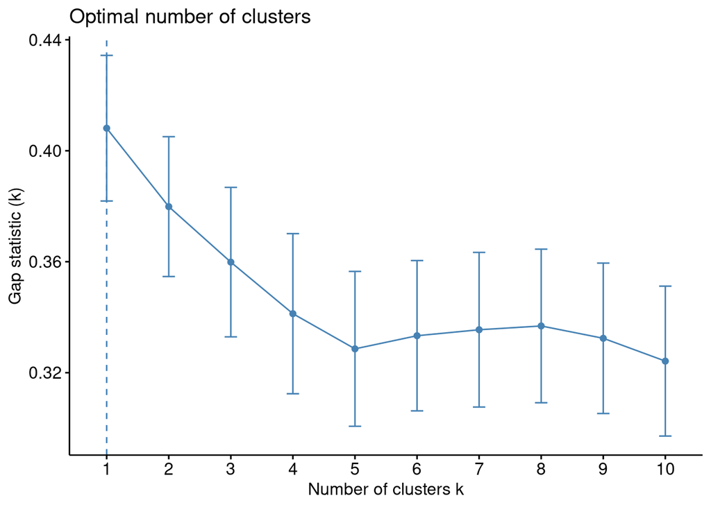

```r
# produce plot of clusters vs. gap statistic

fviz_gap_stat(validate_gap_stat_h)
```

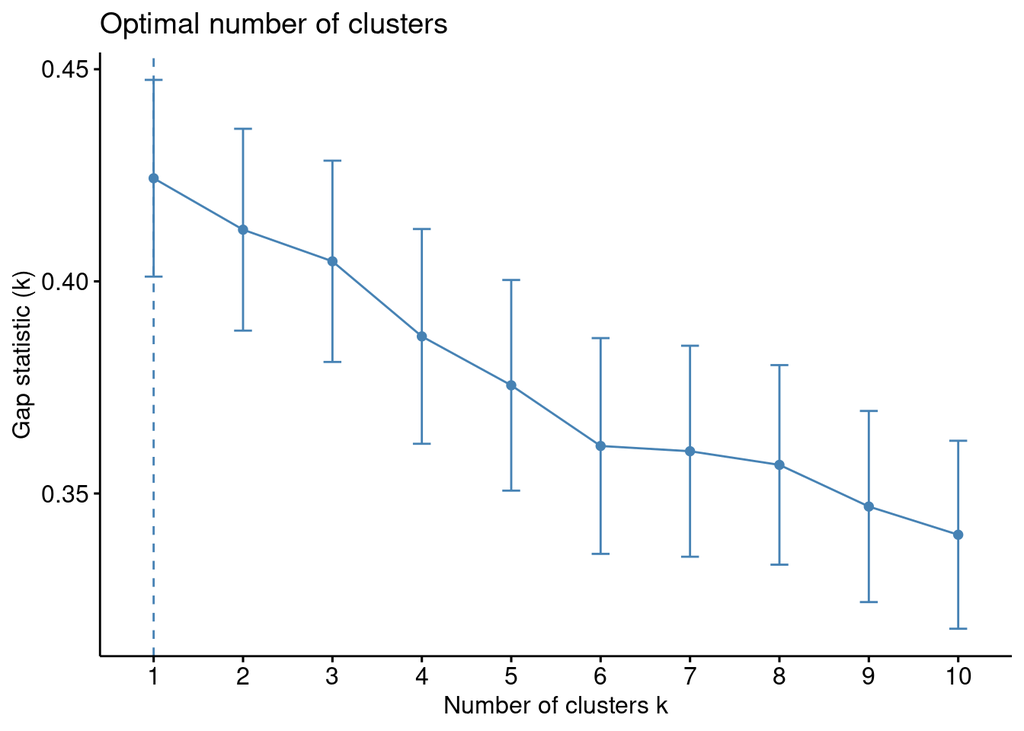

```r
fviz_gap_stat(validate_gap_stat_k)
```

```r
# Finding distance matrix using 3 different distance

validate_distance_mat1 <- dist(validate_fscores, method = 'euclidean')
validate_distance_mat2 <- dist(validate_fscores, method = 'maximum')
validate_distance_mat3 <- dist(validate_fscores, method = 'manhattan')
```

```r
# Fitting Hierarchical clustering Model to dataset

set.seed(85)  # Setting seed
validate_Hierar_cl_eu <- hclust(validate_distance_mat1, method = "ward")
```

```
## The "ward" method has been renamed to "ward.D"; note new "ward.D2"
```

```r
validate_Hierar_cl_max <- hclust(validate_distance_mat2, method = "ward")
```

```
## The "ward" method has been renamed to "ward.D"; note new "ward.D2"
```

```r
validate_Hierar_cl_man <- hclust(validate_distance_mat3, method = "ward")
```

```
## The "ward" method has been renamed to "ward.D"; note new "ward.D2"
```

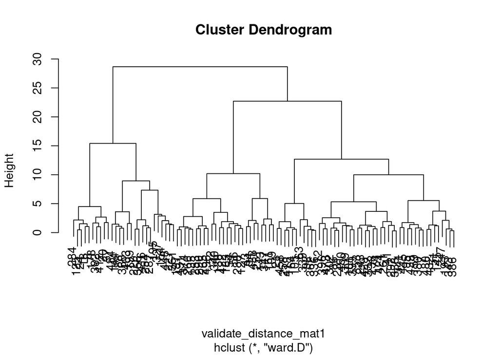

```r
# Plotting dendrogram

plot(validate_Hierar_cl_eu)
```

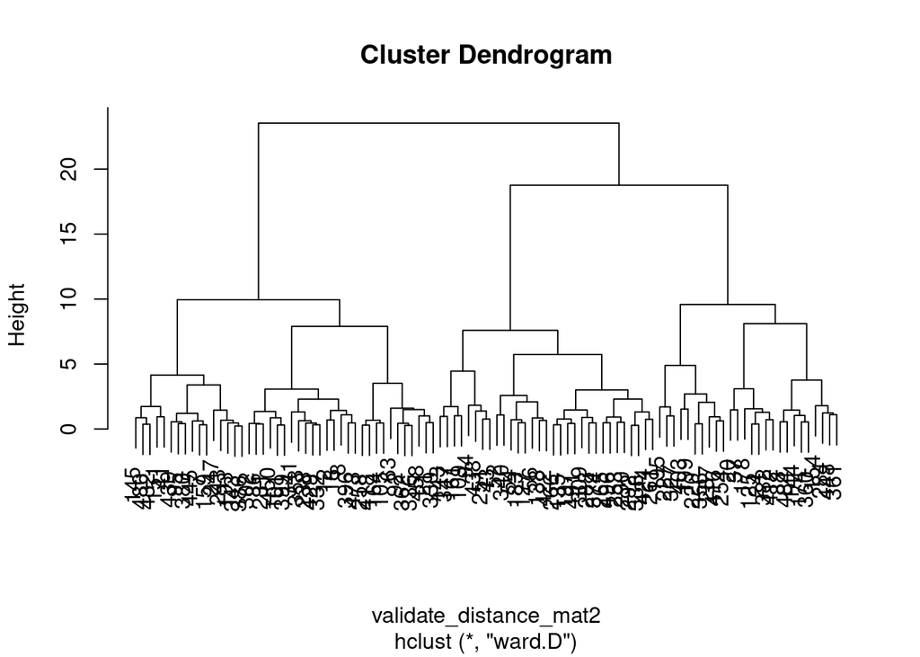

```r
plot(validate_Hierar_cl_max)
```

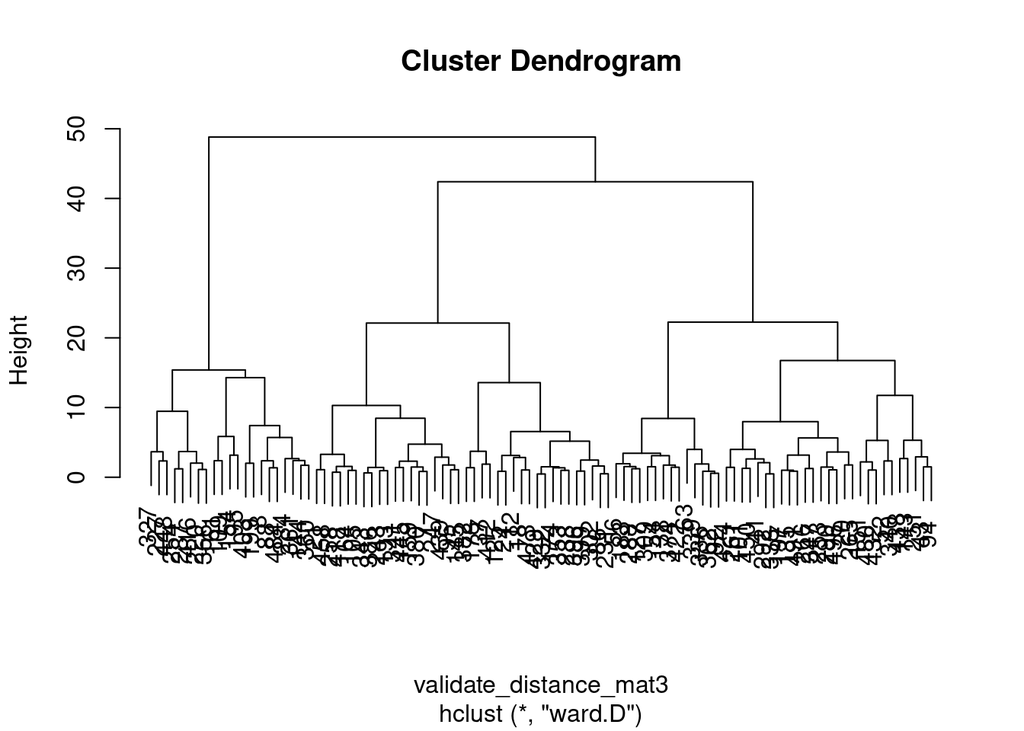

```r
plot(validate_Hierar_cl_man)
```

```r
#suggest 4 group
```

# 3 Clusters - 100 Samples

Hierarchical Euclidean

```r
# Cutting tree by no. of clusters
validate_fit_3_eu <- cutree(validate_Hierar_cl_eu, k = 3 )
validate_fit_3_eu
```

```
## 144  20 362 429 288  95 266 154 416 343 292  12 338 380  86 101 183  88 382 253
##   1   1   2   2   3   2   3   1   1   2   2   2   2   2   2   2   3   1   1   3
## 127   7 332  37  21  18 161 339 265 125 424 396 258 438 251 109 143 309  52 353
##   3   2   2   1   2   1   3   2   3   1   2   2   2   3   3   3   3   2   3   2
## 138 135 412 227 340 341 480 327 450 151  92 432 403 445 448 178 418 195 458 247
##   3   3   1   1   3   2   2   1   2   2   2   2   1   2   1   1   2   1   2   2
## 399 159  43 386 243 254 197  41 231  24 284 484 238 302 473  63  94 347 374 145
##   2   2   3   2   2   1   3   2   2   1   1   1   2   2   2   2   3   3   3   2
## 174 336 491 422   8  56 360 261 439 290 287 361 164 220 105 496 356 199 193  54
##   2   2   3   3   1   3   1   2   2   3   1   1   2   1   2   3   1   1   2   3
```

```r
# Find number of observations in each cluster
table(validate_fit_3_eu)
```

```
## validate_fit_3_eu
##  1  2  3
## 27 47 26
```

```r
# Append cluster labels to original data
validate_final_data_3_eu <- cbind(validate_fscores, cluster = validate_fit_3_eu)

# Display first six rows of final data
head(validate_final_data_3_eu)
```

```
##             TC1        TC2        TC4        TC3 cluster
## 144  1.41729219  1.3212326 -0.8073526  0.1963357       1
## 20  -0.02834488 -0.6336781  1.2710286  2.3026561       1
## 362 -0.46602092  0.2707271  0.2654087 -1.2501171       2
## 429 -0.38414276  0.1738404 -0.7936397  0.5375001       2
## 288 -0.36120597 -0.1345210  0.9946053 -0.6622895       3
## 95  -1.04562855 -1.0248307 -1.0040383 -0.2845974       2
```

```r
# Find mean values for each cluster
validate_hcentres_3_eu <-aggregate(x=validate_final_data_3_eu, by=list(cluster=validate_fit_3_eu), FUN="mean")
print(validate_hcentres_3_eu)
```

```
##   cluster        TC1        TC2        TC4        TC3 cluster
## 1       1  0.6904738  0.9046455  0.1264683  0.8831201       1
## 2       2 -0.5412098 -0.2214034 -0.5810811 -0.2613937       2
## 3       3  0.2613103 -0.5392103  0.9190833 -0.4445670       3
```

Hierarchical Maximum

```r
# Cutting tree by no. of clusters
validate_fit_3_max <- cutree(validate_Hierar_cl_max, k = 3 )
validate_fit_3_max
```

```
## 144  20 362 429 288  95 266 154 416 343 292  12 338 380  86 101 183  88 382 253
##   1   1   2   2   3   2   3   1   1   2   3   2   3   2   2   2   3   1   1   3
## 127   7 332  37  21  18 161 339 265 125 424 396 258 438 251 109 143 309  52 353
##   3   2   2   1   2   2   3   2   3   1   3   2   2   3   3   3   3   3   3   2
## 138 135 412 227 340 341 480 327 450 151  92 432 403 445 448 178 418 195 458 247
##   3   3   1   1   3   2   2   1   2   2   2   2   1   2   1   1   2   1   2   2
## 399 159  43 386 243 254 197  41 231  24 284 484 238 302 473  63  94 347 374 145
##   2   2   3   2   2   1   3   2   2   1   1   1   2   2   2   2   3   3   3   2
## 174 336 491 422   8  56 360 261 439 290 287 361 164 220 105 496 356 199 193  54
##   1   2   3   3   2   3   1   3   2   3   1   1   2   1   2   3   1   1   2   3
```

```r
# Find number of observations in each cluster
table(validate_fit_3_max)
```

```
## validate_fit_3_max
##  1  2  3
## 26 43 31
```

```r
# Append cluster labels to original data
validate_final_data_3_max <- cbind(validate_fscores, cluster = validate_fit_3_max)

# Display first six rows of final data
head(validate_final_data_3_max)
```

```
##             TC1        TC2        TC4        TC3 cluster
## 144  1.41729219  1.3212326 -0.8073526  0.1963357       1
## 20  -0.02834488 -0.6336781  1.2710286  2.3026561       1
## 362 -0.46602092  0.2707271  0.2654087 -1.2501171       2
## 429 -0.38414276  0.1738404 -0.7936397  0.5375001       2
## 288 -0.36120597 -0.1345210  0.9946053 -0.6622895       3
## 95  -1.04562855 -1.0248307 -1.0040383 -0.2845974       2
```

```r
# Find mean values for each cluster
validate_hcentres_3_max <-aggregate(x=validate_final_data_3_max, by=list(cluster=validate_fit_3_max), FUN="mean")
print(validate_hcentres_3_max)
```

```
##   cluster        TC1        TC2        TC4        TC3 cluster
## 1       1  0.7925817  0.8853948  0.1946880  0.8544094       1
## 2       2 -0.6768935 -0.1463768 -0.6895582 -0.2876308       2
## 3       3  0.2741708 -0.5395504  0.7931972 -0.3176296       3
```

Hierarchical Manhattan

```r
# Cutting tree by no. of clusters
validate_fit_3_man <- cutree(validate_Hierar_cl_man, k = 3 )
validate_fit_3_man
```

```
## 144  20 362 429 288  95 266 154 416 343 292  12 338 380  86 101 183  88 382 253
##   1   2   2   3   2   3   2   1   1   3   2   3   2   3   3   2   2   1   3   2
## 127   7 332  37  21  18 161 339 265 125 424 396 258 438 251 109 143 309  52 353
##   2   3   3   3   3   3   1   2   2   3   2   3   3   2   2   1   2   2   2   3
## 138 135 412 227 340 341 480 327 450 151  92 432 403 445 448 178 418 195 458 247
##   2   2   3   1   2   3   2   1   2   2   2   2   1   3   1   3   3   1   3   3
## 399 159  43 386 243 254 197  41 231  24 284 484 238 302 473  63  94 347 374 145
##   3   3   2   3   3   1   2   2   3   3   1   1   3   3   3   2   2   2   2   3
## 174 336 491 422   8  56 360 261 439 290 287 361 164 220 105 496 356 199 193  54
##   3   2   2   2   1   2   1   2   3   2   1   1   3   1   3   2   1   1   3   2
```

```r
# Find number of observations in each cluster
table(validate_fit_3_man)
```

```
## validate_fit_3_man
##  1  2  3
## 21 41 38
```

```r
# Append cluster labels to original data
validate_final_data_3_man <- cbind(validate_fscores, cluster = validate_fit_3_man)

# Display first six rows of final data
head(validate_final_data_3_man)
```

```
##             TC1        TC2        TC4        TC3 cluster
## 144  1.41729219  1.3212326 -0.8073526  0.1963357       1
## 20  -0.02834488 -0.6336781  1.2710286  2.3026561       2
## 362 -0.46602092  0.2707271  0.2654087 -1.2501171       2
## 429 -0.38414276  0.1738404 -0.7936397  0.5375001       3
## 288 -0.36120597 -0.1345210  0.9946053 -0.6622895       2
## 95  -1.04562855 -1.0248307 -1.0040383 -0.2845974       3
```

```r
# Find mean values for each cluster
validate_hcentres_3_man <-aggregate(x=validate_final_data_3_man, by=list(cluster=validate_fit_3_man), FUN="mean")
print(validate_hcentres_3_man)
```

```
##   cluster         TC1         TC2        TC4        TC3 cluster
## 1       1  1.24513889  1.13557719  0.1714449  0.2734882       1
## 2       2 -0.03935905 -0.54808046  0.6254778 -0.2969544       2
## 3       3 -0.64563673 -0.03620585 -0.7696034  0.1692600       3
```

K-mean (Non-Hierarchical)

```r
# Kmeans clustering

set.seed(85)
validate_k_cl3 <- kmeans(validate_fscores,3,nstart=25)
validate_k_cl3
```

```
## K-means clustering with 3 clusters of sizes 35, 22, 43
##
## Cluster means:
##           TC1         TC2        TC4          TC3
## 1 -0.04471555 -0.52270337  0.7659034 -0.457833359
## 2  1.20746783  0.86139451  0.4896403  0.747108361
## 3 -0.58137786 -0.01525724 -0.8739234 -0.009586427
##
## Clustering vector:
## 144  20 362 429 288  95 266 154 416 343 292  12 338 380  86 101 183  88 382 253
##   2   2   1   3   1   3   1   2   2   3   1   3   1   3   3   3   1   3   2   1
## 127   7 332  37  21  18 161 339 265 125 424 396 258 438 251 109 143 309  52 353
##   1   3   3   3   3   3   2   3   1   3   2   3   3   1   1   2   1   1   1   3
## 138 135 412 227 340 341 480 327 450 151  92 432 403 445 448 178 418 195 458 247
##   1   1   3   2   1   3   1   2   1   3   1   1   2   3   2   2   3   2   3   3
## 399 159  43 386 243 254 197  41 231  24 284 484 238 302 473  63  94 347 374 145
##   3   3   1   3   3   2   1   3   1   3   2   3   3   1   3   3   1   1   1   3
## 174 336 491 422   8  56 360 261 439 290 287 361 164 220 105 496 356 199 193  54
##   3   1   1   1   3   1   3   2   3   2   1   2   3   2   3   1   2   2   3   1
##
## Within cluster sum of squares by cluster:
## [1] 71.95610 82.64835 90.55260
##  (between_SS / total_SS =  38.1 %)
##
## Available components:
##
## [1] "cluster"      "centers"      "totss"        "withinss"     "tot.withinss"
## [6] "betweenss"    "size"         "iter"         "ifault"
```

# Validate - Accuracy Rate

check different if value are assign to the same cluster to validate

Euclidean

```r
Validate_table_3_eu <- data.frame(fit_3_eu)
Validate_table_3_eu <- Validate_table_3_eu[validate_indices, ]

df_fit_validate_3_eu <- data.frame(Difference= Validate_table_3_eu - validate_fit_3_eu)


# Count the number of 0s in 'Column1'_zero
num_zeros_3_eu <- nrow(filter(df_fit_validate_3_eu,Difference == 0))

# Calculate the total number of rows in the dataframe
total_rows_3_eu <- nrow(df_fit_validate_3_eu)

# Calculate the proportion of zeros
proportion_zeros_3_eu <- num_zeros_3_eu / total_rows_3_eu

# Print the proportion of the correctly assign cluster
print(proportion_zeros_3_eu)
```

```
## [1] 0.71
```

Maximum

```r
Validate_table_3_max <- data.frame(fit_3_max)
Validate_table_3_max <- Validate_table_3_max[validate_indices, ]

df_fit_validate_3_max <- data.frame(Difference= Validate_table_3_max - validate_fit_3_max)


# Count the number of 0s in 'Column1'_zero
num_zeros_3_max <- nrow(filter(df_fit_validate_3_max,Difference == 0))

# Calculate the total number of rows in the dataframe
total_rows_3_max <- nrow(df_fit_validate_3_max)

# Calculate the proportion of zeros
proportion_zeros_3_max <- num_zeros_3_max / total_rows_3_max

# Print the proportion of the correctly assign cluster
print(proportion_zeros_3_max)
```

```
## [1] 0.7
```

Manhattan

```r
Validate_table_3_man <- data.frame(fit_3_man)
Validate_table_3_man <- Validate_table_3_man[validate_indices, ]

df_fit_validate_3_man <- data.frame(Difference= Validate_table_3_man - validate_fit_3_man)


# Count the number of 0s in 'Column1'_zero
num_zeros_3_man <- nrow(filter(df_fit_validate_3_man,Difference == 0))

# Calculate the total number of rows in the dataframe
total_rows_3_man <- nrow(df_fit_validate_3_man)

# Calculate the proportion of zeros
proportion_zeros_3_man <- num_zeros_3_man / total_rows_3_man

# Print the proportion of the correctly assign cluster
print(proportion_zeros_3_man)
```

```
## [1] 0.19
```

K-mean

```r
df_kmean_valid_3 <- data.frame(k_cl3["cluster"])
df_kmean_valid_3 <- df_kmean_valid_3[validate_indices, ]

K_validate_3 <- cl_predict(k_cl3,newdata = validate_fscores)

df_kfit_validate_3 <- data.frame(Difference= df_kmean_valid_3 - K_validate_3 )


# Count the number of 0s in 'Column1'_zero
num_zeros_k_3 <- nrow(filter(df_kfit_validate_3,Difference == 0))

# Calculate the total number of rows in the dataframe
total_rows_k_3 <- nrow(df_kfit_validate_3)

# Calculate the proportion of zeros
proportion_zeros_k_3 <- num_zeros_k_3 / total_rows_k_3

# Print the proportion of the correctly assign cluster
print(proportion_zeros_k_3)
```

```
## [1] 0.89
```

Recluster K-mean

```r
New_K_CLust <- df_kmean_valid_3 - data.frame(validate_k_cl3["cluster"])
New_K_CLust
```

```
##     cluster
## 144       0
## 20       -1
## 362       2
## 429       0
## 288       0
## 95        0
## 266       0
## 154       0
## 416       0
## 343       0
## 292       2
## 12        0
## 338       0
## 380       0
```

[output cut: 86 more lines]

```r
# Count the number of 0s in 'Column1'_zero
num_zeros_k_3_re <- nrow(filter(New_K_CLust ,cluster == 0))

# Calculate the total number of rows in the dataframe
total_rows_k_3_re <- nrow(New_K_CLust)

# Calculate the proportion of zeros
proportion_zeros_k_3_re <- num_zeros_k_3_re/total_rows_k_3_re

# Print the proportion of the correctly assign cluster
print(proportion_zeros_k_3_re)
```

```
## [1] 0.79
```

Plot K-mean cluster

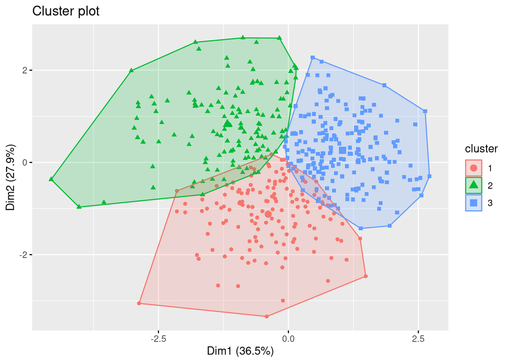

```r
#Visualize clustering results for K = 3
plot_kcluster <- fviz_cluster(k_cl3, data = fscores, geom = "point")
plot_kcluster
```

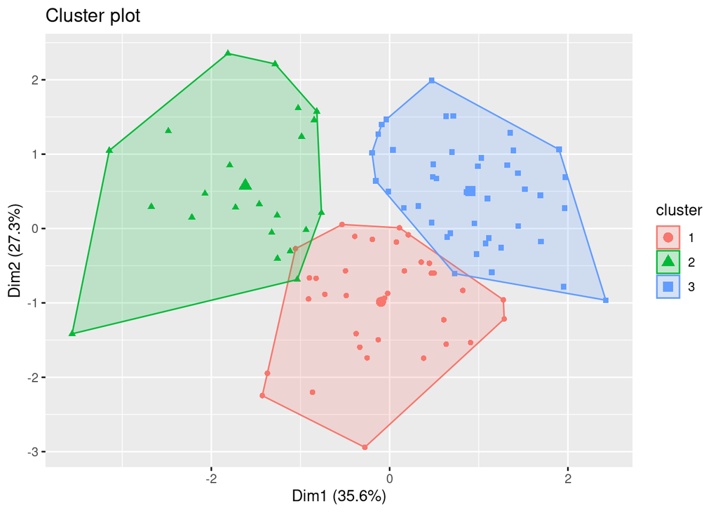

```r
# Visualize clustering results for K = 3 - validate set
plot_kcluster_validate <- fviz_cluster(validate_k_cl3 , data = validate_fscores,geom="point")
plot_kcluster_validate
```